# AI for Superconductivity: A Systematic Map and Readiness Assessment

Mingguang Chen<sup>1,*</sup>, Bo Qu<sup>1</sup>

<sup>1</sup>DeepGrounding. *Corresponding author: deepgroundingai@gmail.com

2026-09-09

Abstract

Superconductivity research generates enormous quantities of data and has a poor record of predicting its own discoveries, which makes it an obvious target for AI for Science and a poorly understood one. Every arXiv preprint filed under cond-mat.supr-con between September 2021 and September 2026 was harvested month by month, giving 10,303 records, of which 10,049 survive off-topic filtering at a measured bleed rate of 2.5%; a targeted supplement adds 200 records. Each is classified along two axes – material family and mode of inquiry – by a language-model pass agreeing with hand labels at 86.3% and 87.0%, per-class recall reported. We then assess 15 of the grid’s 45 cells for data availability, benchmark maturity and validation cost. Machine learning has barely entered the field: 1.2% of the seed uses an AI method in its own work. Where it has entered it clusters in ab initio screening and neural quantum states, where a calculation can check a prediction, and in device metrology, where instruments label their own output; we offer validation cost as the hypothesis fitting that pattern, untested against data volume or scientific stakes. Synthesis, the rate-limiting step across families, carries no AI-tagged paper in the seed and one in the merged corpus. The gap between prediction and measurement is concrete: recent screens advertise candidates above 200 K at 200 GPa, while the closed prediction-synthesis-measurement loops found here delivered low-temperature intermetallics, 2.5 to 6.5 K at ambient pressure in the more recent. We conclude that the highest-value interventions are releasing labelled characterization data, building a time-stamped benchmark of experimentally confirmed superconductors, and modelling synthesizability rather than automating synthesis. Corpus, labels and scripts are released.

# 1 Introduction

Superconductivity is an unusually well-instrumented field with an unusually poor prediction record. A century after Onnes, the mechanism of the highest-*T*<sub>*c*</sub> families is still contested, the compounds that matter were mostly found by chemical intuition and persistence, and two of the most prominent recent claims of room-temperature superconductivity have been retracted. It is exactly the sort of field that AI-for-Science rhetoric promises to transform.

Whether it can, and where, is an empirical question about the field’s structure rather than about the capability of models. A machine-learning method needs three things: data in a form it can consume, a target quantity worth predicting, and a way of finding out whether a prediction was right. Different parts of superconductivity research supply these to wildly different degrees. High-pressure hydride work has a computable target and a mature calculation pipeline. Cuprate physics has four decades of spectra and no agreed quantity to predict. Thin-film synthesis has the field’s real bottleneck and almost no machine-readable record of what has been tried.

This survey makes that structure explicit. We harvest every arXiv preprint filed under `cond-mat.supr-con` between September 2021 and September 2026, classify each along two axes – the material family it studies and the mode of inquiry it uses – and then evaluate the cells of the resulting grid for what a machine-learning method could contribute to them. The corpus is 10,249 records after off-topic filtering, and the classification is validated against hand labels with the agreement rates and per-class recall reported in full.

Three results follow. Machine learning has barely entered this field: 1.2% of the systematically harvested corpus uses an AI method in its own work. Where it has entered, it tracks validation cost, clustering in the cells where a calculation can check a prediction and in device metrology where instruments generate their own labels, rather than in the cells with the most data or the greatest scientific stakes. And the field’s actual bottleneck is the emptiest cell: synthesis, which carries no AI-tagged paper in the systematic seed at all, and one in the merged corpus.

The contribution is therefore threefold: a systematically harvested and openly released corpus of the field’s recent literature; a two-axis taxonomy that has been tested against hand labels rather than asserted; and a per-cell assessment of AI readiness that identifies where effort is likely to pay off and, more usefully, where current enthusiasm is misdirected. Section 2 fixes the vocabulary, states the taxonomy, positions the survey against existing reviews and documents the corpus. Sections 3 and 4 walk the two axes. Section 5 reports what AI has actually done in this field, critical literature included. Section 6 gives the readiness assessment for 15 selected cells and the resulting priorities. Section 7 asks what the emerging AI-for-science infrastructure would have to deliver for the field’s central target to come within reach, and what would falsify that route. Section 8 offers three testable hypotheses about why the field looks the way it does.

# 2 Preliminaries and taxonomy

## 2.1 Terms this field overloads

A survey that spans nine material families and five modes of work has to fix its vocabulary first, because several of the terms below carry different meanings in different corners of the literature.

*Critical temperature.* *T*<sub>*c*</sub> is quoted from several inequivalent operational definitions: the onset of a resistive drop, the midpoint of the transition, the zero-resistance point, and the temperature at which diamagnetic screening appears. The gap between onset and zero resistance is small in clean conventional samples and large in inhomogeneous ones, which is exactly where contested claims live. Throughout this survey we say which definition a reported number uses when the distinction bears on the claim, and we treat a resistive onset without a magnetic signature as weaker evidence than the two together.

*Conventional and unconventional.* We use *conventional* to mean pairing mediated by electron-phonon coupling and describable within Migdal-Eliashberg theory (Bardeen et al. 1957), and *unconventional* to mean a gap function that changes sign or breaks a lattice symmetry, whatever the glue. High-pressure hydrides are therefore conventional in mechanism while being extreme in *T*<sub>*c*</sub>, and this survey groups them with the electron-phonon family rather than with the cuprates they are often headlined against.

*Prediction versus discovery.* A computed structure with a favourable calculated *T*<sub>*c*</sub> is a prediction. A material that has been made and measured is a discovery. Papers routinely use “discovery” for the former, and the AI-for-materials literature does so more often than the superconductivity literature does. We reserve *discovery* for the experimental sense and say *predicted candidate* otherwise. This distinction carries most of the weight in Section 5.

*AI-discovered.* We treat a material as AI-discovered only when a machine-learning model selected or generated the candidate, the material was subsequently synthesised, and superconductivity was measured. Weaker uses of the phrase – a screen that ranked a known compound highly, or a model that reproduced a *T*<sub>*c*</sub> after the fact – are described as such.

## 2.2 The two axes

The taxonomy has two axes plus a lens (Figure 1).

*Axis 1, material family*, is what the paper is about: `conv` (conventional and electron-phonon systems, including high-pressure hydrides), `cuprate`, `febased`, `nickelate`, `unconv_other` (heavy fermion, ruthenate, organic, noncentrosymmetric bulk systems), `lowd` (two-dimensional, interface, moiré and kagome systems), `topo` (topological superconductivity and Majorana platforms), `device` (qubits, detectors, magnets, cables, circuits), and `general` (material-agnostic theory, formalism and instrumentation).

*Axis 2, mode of inquiry*, is how the work was done: `theory`, `abinitio`, `discovery`, `synthesis`, `characterization`. This axis deliberately does not encode whether a topic is applied. An earlier version of this taxonomy carried a sixth value, `application`, and it failed a measurement: it mixed *how* the work was done with *what it was for*, and characterization-versus-application was the single largest source of disagreement both for keyword rules and for two independently benchmarked language models. Application context is carried by the `device` family instead, so a qubit paper is labelled theory, synthesis or characterization like any other paper.

*The AI lens* applies only to papers that use a machine-learning method in their own work: `surrogate` (regression and classification models, symbolic regression), `gnn_potential` (graph networks and machine-learned interatomic potentials), `generative` (diffusion, VAE, flow models for structures and compositions), `llm` (language models, agents, literature mining), `nqs` (neural quantum states), and `autonomous_exp` (self-driving laboratories, closed-loop active learning).

The axes are the contribution of this survey, and Sections 3 through 5 are organised along them. Section 6 evaluates 15 selected cells for what AI can currently do in them.

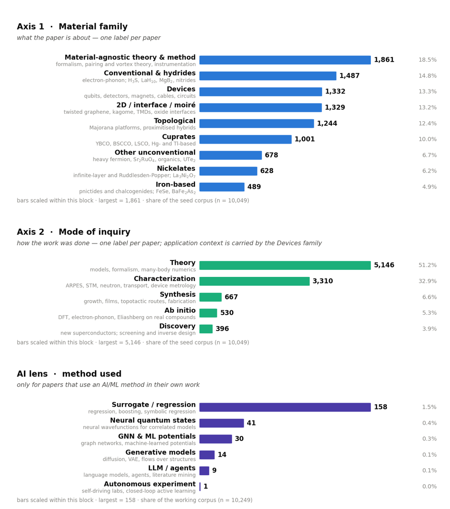

Figure 1: The taxonomy and its occupancy. Every corpus record carries one label from Axis 1 and one from Axis 2; the AI lens applies only to records that use a machine-learning method in their own work. Labels are sorted by count within each block and bars are scaled within a block, since the three blocks are different populations. Family and mode counts are seed-corpus papers on the same basis as Table 1, so the two agree; the AI-lens counts are over the whole working corpus. Two features carry into later sections: theory alone is 51.2% of the corpus, and the entire AI lens is 253 papers, of which one is an autonomous experiment.

## 2.3 Positioning relative to existing surveys

Two bodies of review literature already cover parts of this ground, and neither covers the join.

The first is per-family physics reviews. Recent examples treat nickelate superconductivity (Y. Wang et al. 2025; Zhang et al. 2026) and the hydride programme. These are authoritative on mechanism and materials, and they say little about method infrastructure: what data exists, what is measurable at scale, where a model could be trained or tested.

The second is machine-learning-for-superconductors reviews. Recent examples survey materials-informatics approaches to superconductor discovery (Tran et al. 2024), machine-learning searches for new superconductors (Adiga and Waghmare 2026), AI-driven high-throughput screening (Gashmard et al. 2025), and language-model workflows for extraction and property prediction (Itani et al. 2025; Li et al. 2026). These are organised by method, and their material scope is dominated by the one task where tabulated data happens to exist – predicting *T*<sub>*c*</sub> from composition.

This survey takes the join as its subject. It maps the whole field onto a family-by-mode grid, populates that grid from a systematically harvested corpus, and then asks of the cells it scores what would have to be true for a machine-learning method to contribute there. The result is a statement about where the opportunities are *not*, which the method-organised reviews cannot make because they only look where the methods already are.

## 2.4 Corpus construction

*Seed harvest.* Every arXiv preprint listed under `cond-mat.supr-con`, as primary category or cross-list, submitted between 2021-09-01 and 2026-09-07, retrieved month by month through the arXiv API. This is a systematic, not a keyword, harvest: the selection criterion is the category label the authors themselves chose. It yields 10,303 records, of which 6,986 carry `cond-mat.supr-con` as primary category and 3,317 are cross-listed from elsewhere. Raw responses are cached per month so the harvest is reproducible.

*Targeted supplement.* The seed necessarily misses AI-for-materials work that never touches the superconductivity category. Two supplementary threads were harvested by keyword: AI applied to superconductivity from adjacent categories, and general AI-for-materials infrastructure needed for Section 6. These add 691 records tagged `supplement_t1` and `supplement_t2`. The supplement is recency-biased by construction – its queries are capped and sorted by submission date – so it is excluded from every growth statistic and from Table 1’s family-by-mode counts, where it appears only as a separate column.

*Off-topic filtering.* 745 records were flagged as not about superconductivity and excluded from all statistics. Within the systematically harvested seed the rate is 254 of 10,303, or 2.5%, which is this corpus’s measured query-bleed. The rate is far higher in the supplement, as intended: the general AI-for-materials thread was designed to reach outside the field. After exclusion the working corpus is 10,249 records: 10,049 seed and 200 supplement.

*Labelling.* Both axes and the AI lens were assigned by a language-model pass over title and abstract (`gemini-3.5-flash-lite`), after keyword rules were measured and found inadequate. The hand-labelled sample is 150 stratified records, of which four were hand-marked as query bleed and carry no mode, so both agreement figures below are scored on the remaining 146 – 126 of 146 on family, 127 of 146 on mode:

| labels | family | mode of inquiry |
| --- | --- | --- |
| keyword rules | 80.1% | 70.5% |
| language-model pass | 86.3% | 87.0% |

Per-class recall is 100% (theory, 57/57), 90% (characterization, 47/52), 85% (ab initio, 11/13), 64% (synthesis, 7/11) and 38% (discovery, 5/13). The two small classes are the weak ones, and the denominators are the reason to be careful with them: on thirteen papers a single reclassification moves recall by eight points, so these percentages carry roughly the information of the counts beside them. One claim in this survey does rest on them, and it should be read with that in mind: the near-absence of AI-tagged synthesis work depends on both synthesis recall (64%) and AI recall (77%), and both errors run in the direction of undercounting. The AI lens was validated separately against 120 hand-labelled records, half drawn from each side of the rule-based tag: 88% precision and 77% recall on the AI-versus-not decision, 82% exact agreement on which method.

*These figures score the labels that ship with this paper*, not a fresh model run. `llm_label.py --score-published` reads the released label cache and the released truth set and reproduces every number above; the `--benchmark` mode re-queries the model and is used only for choosing between models, since its result depends on a run the reader cannot repeat.

*Taxonomy revision, disclosed.* The two agreement figures above are not measured against the same label set. The task axis originally carried a sixth value, `application`; the first labelling round showed that characterization-versus- application was the dominant disagreement for the keyword rules and for both benchmarked language models alike, which identified the value as conflating mode of work with purpose rather than as a classifier failure. The value was removed, the 146 scored hand labels were remapped accordingly, and the models were re-scored against the revised set. The 70.5% rule figure predates that revision and is reported for completeness rather than as a like-for-like comparison. The prompt was also sharpened once, after per-class recall showed synthesis at 55%, by adding explicit synthesis-versus-characterization and discovery-versus-ab-initio boundary rules; the corpus was then relabelled from scratch with the final prompt.

*Annotator disclosure.* All hand labels were produced by a single annotator, in the same working session that built the pipeline. The figures above are therefore agreement between one human pass and one model pass, not accuracy against an external ground truth. Corpus, labels, prompts and scripts are released so that both passes can be re-run and re-scored.

*Citation counts.* Citation data comes from OpenAlex, resolved for 8,280 of the records. Over a five-year window raw counts favour older work mechanically, so where this survey ranks papers it ranks by citations per month since submission, and citation counts for work less than a year old are not read as impact at all.

Table 1: Corpus by material family and mode of inquiry. Counts are seed records after off-topic filtering; the supplement is listed separately because it is recency-biased by construction and is excluded from all trend statistics.

| Family | Theory | Ab init. | Discov. | Synth. | Charac. | Seed | Suppl. |
| --- | --- | --- | --- | --- | --- | --- | --- |
| Conventional | 197 | 237 | 271 | 193 | 589 | 1487 | 15 |
| Cuprate | 445 | 54 | 7 | 58 | 437 | 1001 | 2 |
| Iron-based | 95 | 15 | 4 | 58 | 317 | 489 | 0 |
| Nickelate | 212 | 113 | 20 | 74 | 209 | 628 | 1 |
| Other unconv. | 320 | 10 | 20 | 22 | 306 | 678 | 0 |
| 2D / moiré | 594 | 74 | 38 | 65 | 558 | 1329 | 10 |
| Topological | 909 | 14 | 8 | 37 | 276 | 1244 | 9 |
| Devices | 611 | 4 | 2 | 156 | 559 | 1332 | 109 |
| Material-agnostic | 1763 | 9 | 26 | 4 | 59 | 1861 | 54 |
| Total | 5146 | 530 | 396 | 667 | 3310 | 10049 | 200 |

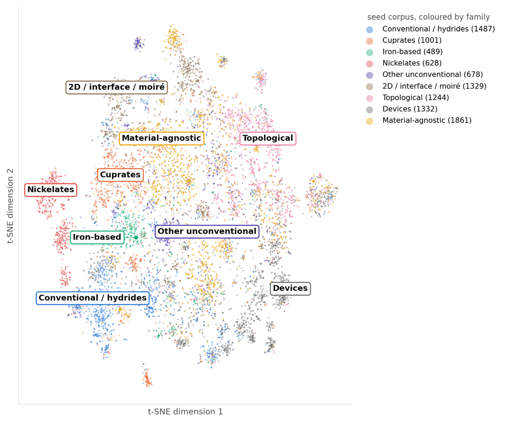

Figure 2: Semantic map of the seed corpus (TF-IDF, truncated SVD, t-SNE), coloured by material family. Each family is labelled at its density peak, with a leader line where the label had to be moved to avoid a collision; nine categorical hues cannot be told apart reliably, so the labels rather than the colours carry identity. Per-family counts match Table 1.

*Limitations.* The corpus is arXiv-only, so it inherits arXiv’s coverage: strong in theory and condensed-matter experiment, weaker in applied-superconductivity engineering that publishes in IEEE venues, and blind to unpublished industrial work, which matters most for the device family. Category self-assignment means a paper whose authors did not cross-list to `cond-mat.supr-con` is absent from the seed regardless of content. Labels are single-label where reality is often multi-label: a paper that grows a crystal and measures it gets one mode, chosen by which the abstract presents as the contribution.

# 3 Material families

This section walks Axis 1. Each family is treated for what it is currently doing, what is open, and – because that is this survey’s purpose – what kind of data it generates. Counts are seed-corpus counts from Table 1 and Figure 2.

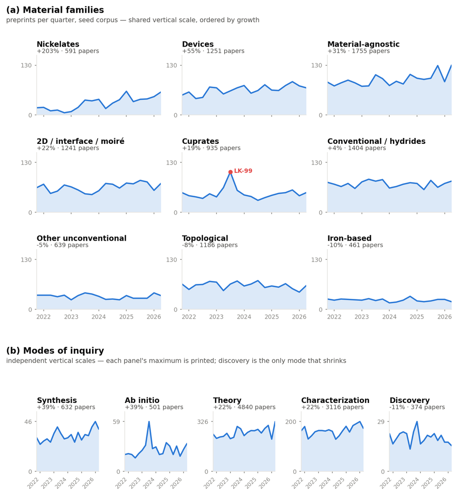

Figure 3: Quarterly submissions, seed records only, drawn as small multiples rather than as one nine-line overlay. Panels are ordered by growth, measured as the change from the first four to the last four complete quarters, and that figure is printed on each panel. The nine family panels (a) share one vertical scale so magnitudes stay comparable; the five mode panels (b) use independent scales, each with its maximum printed, because a shared scale renders the three smaller modes as flat lines. Both partial endpoint quarters are omitted. The marked cuprate spike in 2023Q3 is the LK-99 replication burst discussed in the text.

## 3.1 Nickelates: the fast-moving family

Nickelates are among the smaller named families in this corpus (628 seed records) and by a wide margin the fastest-growing: quarterly output rose 203% between the first and last four quarters of the window, against +55% for the next fastest (Figure 3a). The line begins outside the window with superconductivity in an infinite-layer nickelate thin film (Li et al. 2019), and turns sharply with the report of superconductivity near 80 K in La<sub>3</sub>Ni<sub>2</sub>O<sub>7</sub> above 14 GPa (Sun et al. 2023).

What followed is a useful case study in how a modern materials claim is stabilised. The original report lacked zero resistance; that was supplied under a liquid pressure medium, together with strange-metal *T*-linear resistivity whose coefficient tracks the superconducting transition under pressure (Zhang et al. 2024). Polycrystalline samples then reproduced the effect, reaching zero resistivity at 9 GPa and 35.6 K at 14.5 GPa (Wang et al. 2024). In parallel, careful high-pressure work reported that the superconductivity is filamentary rather than bulk, and tied the inconsistent reproducibility to oxygen content (Zhou et al. 2023). Bulk superconductivity with zero resistivity and a Meissner signal was subsequently reported in flux-grown La<sub>2</sub>SmNi<sub>2</sub>O<sub>7 − *δ*</sub> single crystals, at 92 K onset and 73 K zero-resistance at 21.6 GPa (Li et al. 2025).

The pressure requirement is the family’s practical obstacle, and thin-film strain engineering is the route around it. Compressively strained (La,Pr)<sub>3</sub>Ni<sub>2</sub>O<sub>7</sub> films on SrLaAlO<sub>4</sub> gave an ambient-pressure onset of 45 K with a Berezinskii-Kosterlitz-Thouless-like transition at 9 K (Zhou et al. 2025), and a subsequent extreme non-equilibrium growth regime raised the onset to about 63 K with zero resistance near 37 K (Zhou et al. 2026). The gap between onset and zero-resistance temperatures in these films is exactly the definitional issue flagged in Section 2, and it is the reason both numbers are quoted here.

Theory moved at the same pace, converging quickly on bilayer two-orbital models built from first-principles band structures, with *s*<sub>±</sub> pairing driven by the Ni *d*<sub>*z*<sup>2</sup></sub> orbital and its interlayer exchange (Gu et al. 2025; Luo et al. 2023; Sakakibara et al. 2024; Shen et al. 2023). For AI purposes the nickelate story is instructive in a discouraging way: the rate-limiting steps were sample quality, oxygen stoichiometry and pressure technique. None of them is a prediction problem.

## 3.2 Conventional superconductors and hydrides: prediction that outruns measurement

The conventional family is the corpus’s largest single-material grouping (1,487 seed records) and the only one where computational prediction routinely precedes experiment. Its anchors are the 203 K report in the sulfur hydride system (Drozdov et al. 2015) and the lanthanum superhydride results near 250-260 K (Drozdov et al. 2019; Somayazulu et al. 2019). Within the window the programme continues at megabar pressures, with reports in cerium superhydrides (Semenok et al. 2023; Cao et al. 2024), Ca-Mg ternary superhydrides above 180 K (Cai et al. 2023), and a claim of superconductivity with onset between 271 and 298 K in a La-Sc-H system at 195-266 GPa (Song et al. 2025). That last claim is recent, singular and not independently replicated at the time of writing, and the retraction record discussed below is the reason to say so explicitly rather than to quote the number alone.

This family also carries the field’s heaviest evidential burden. Two prominent claims were retracted (Snider et al. 2020; Dasenbrock-Gammon et al. 2023). The Lu-N-H episode is still unsettled rather than closed: one group reported resistance measurements in good agreement with the original transition temperature and its pressure dependence (Salke et al. 2023), while several others reported no superconductivity in samples they prepared, and first-principles modelling of the plausible parent structures concluded that the observed Raman spectrum matches LuH<sub>3</sub>, that the pressure-driven colour change is an optical property of LuH<sub>2</sub> requiring no structural transition, and that neither compound superconducts at high temperature (Dangić et al. 2023). Methodological argument continues over what counts as proof at these pressures, including whether flux-trapping magnetisation demonstrates superconductivity in H<sub>3</sub>S (Tallon 2024).

This family is where AI-assisted screening is concentrated, for a reason Section 6 formalises: the target quantity is the Eliashberg *T*<sub>*c*</sub>, which is computable, so a model can be trained and checked without a diamond anvil cell. The distribution in Table 1 shows the consequence – conventional systems carry 237 of the corpus’s 530 ab initio records and 271 of its 396 discovery records, more than any other family in both.

## 3.3 Cuprates: mature physics, and a cautionary spike

Cuprates account for 1,001 seed records, dominated by characterization (437) and theory (445), with only 7 discovery records. Forty years after the original observation (Bednorz and Müller 1986), the open question is still the mechanism, and the work is correspondingly weighted toward precision measurement of known compounds and model studies of the doped Hubbard and *t*-*J* systems.

The family’s most striking corpus feature is an artefact worth reporting. Ranked by citations per month, the top of the cuprate list is not cuprate physics at all: it is LK-99, the Cu-substituted lead apatite claimed as a room-temperature ambient-pressure superconductor (Lee, J.-H. Kim, et al. 2023; Lee, J. Kim, et al. 2023). The classifier placed these in the cuprate family because the material is a copper oxide compound, which is defensible chemically and wrong physically. It is worth quantifying rather than merely noting: 51 of the family’s 1,001 seed records mention LK-99 or the lead apatite, and 41 of them fall in 2023Q3, which is 39% of that quarter’s 105 cuprate records. The cuprate row of Table 1 is inflated by that much. The growth figure on the cuprate panel of Figure 3a is not: the burst sits mid-window and misses both endpoint windows, so the family’s +19% is unchanged when the 51 rows are removed. No other family is measurably affected. We report the labels as the released classifier produced them rather than patching them afterwards, because the agreement figures in Section 2 are scored against that same label file; a reader who wants the corrected cuprate series can drop those 51 rows. The episode is visible in Figure 3a as a sharp cuprate spike in 2023Q3, and it resolved quickly: phase-pure single crystals proved highly insulating and optically transparent with no transition anomalies, ruling out superconductivity (Puphal et al. 2023). The episode is also a good example of how first-principles work enters a live controversy on both sides: Griffin’s density-functional calculations identified correlated isolated flat bands at the Fermi level, noting these as a signature associated with high transition temperatures (Griffin 2023), which made the compound worth taking seriously even as the crystals were failing to superconduct. The replication burst is the most compressed example in this corpus of the field’s self-correction working, and of how quickly a high-visibility claim distorts the literature’s shape.

## 3.4 Iron-based superconductors: consolidation

At 489 seed records, iron-based systems are the smallest named family and show the steepest decline in quarterly output over the window, at -10%; topological (-8%) and other unconventional systems (-5%) are the only others that fall at all (Figure 3a). Fifteen years after the founding report (Kamihara et al. 2008), the work is consolidation: orbital-selective pairing assisted by Hund’s coupling in Ba<sub>1 − *x*</sub>K<sub>*x*</sub>Fe<sub>2</sub>As<sub>2</sub> (Corbae et al. 2026), sign-reversal gap structure in FeTe<sub>0.55</sub>Se<sub>0.45</sub> (Hou et al. 2025), time-reversal-symmetry-breaking states (Bärtl et al. 2025), and vortex-matter studies (Sánchez et al. 2023; Iguchi et al. 2023). The family is characterization-dominated (317 of 489), and it is the one where the phase diagram is best mapped, which makes it the most plausible near-term source of the labelled spectral datasets Section 6 argues for.

## 3.5 Two-dimensional, interface and moiré systems

For this survey the important property is that these systems are device-like: each sample is a fabricated stack, gate-tunable, and measured with electrical transport. That generates dense, structured, parameterised data of exactly the kind a model can use – and simultaneously makes each sample expensive and non-identical, which is why the family scores well on data and poorly on validation cost in Figure 5.

## 3.6 Topological superconductivity

At 1,244 seed records, this family is theory-heavy (909 of 1,244) in a way no other family matches. The experimental programme has consolidated around quantum-dot-based minimal Kitaev chains (Dvir et al. 2023; Tsintzis et al. 2024; Bordin et al. 2024) rather than the earlier bare-nanowire route, which is itself a response to a decade of contested zero-bias-peak evidence. Josephson diode physics runs through this family and into devices (Mazur et al. 2022; Lotfizadeh et al. 2024).

The theory-to-experiment ratio here is the sharpest warning in the corpus about reading activity as progress. It is also, from the AI standpoint, the least tractable cell: what a model would predict is unclear when the disagreement is about what a measurement means.

## 3.7 Other unconventional systems

This family (678 seed records) collects heavy-fermion, ruthenate, organic and noncentrosymmetric compounds. Two currents dominate the window: UTe<sub>2</sub>, where triplet superconductivity is studied in progressively cleaner crystals (Wu et al. 2024) following the original spin-triplet report (Ran et al. 2019), and where an earlier claim of time-reversal-symmetry breaking did not survive: Kerr measurements across samples grown by two different routes found no evidence for a spontaneous signal (Ajeesh et al. 2023), and the arrival of altermagnetism as a cross-cutting concept (Mazin 2025), now reaching into diode effects (Schrade et al. 2026) and Cr-based kagome systems (Xu et al. 2025; Peng et al. 2025). This family is the clearest case of small-sample physics: crystal quality is the experiment, which is why it is characterization-heavy (306) and nearly synthesis-free in the corpus (22).

## 3.8 Devices and applications

At 1,332 seed records this family is large, and it is the one whose corpus representation is least trustworthy: much applied superconductivity publishes in IEEE venues that arXiv’s `cond-mat.supr-con` category does not capture, and industrial qubit work is under-posted. What the corpus does capture is materials-limited qubit physics – dielectric loss in nitride films (Deng et al. 2022), niobium film structure and circuit losses (Drimmer et al. 2024), quasiparticle poisoning from phonon bursts (Anthony-Petersen et al. 2024) – along with scaling roadmaps (Mohseni et al. 2024; Aasen et al. 2025).

This is where the survey’s AI story is most positive, and Section 5 explains why: the family’s measurements are machine-generated, standardised and high-volume, so characterization models have a real training signal. It is the only cell in Figure 5 that scores 3 on data availability for a measurement task.

## 3.9 Material-agnostic theory and method

The largest single label in the corpus is not a material at all: 1,861 seed records are material-agnostic theory, formalism and instrumentation. That a residual category is modal is a finding rather than a bookkeeping artefact, and the sample inspection behind Table 1 shows what it contains – Josephson and diode phenomenology (Nadeem et al. 2023; Kochan et al. 2023; Wang et al. 2022), Hubbard-model studies not tied to one compound (Xu et al. 2024), topological field theory of the superconducting state (Verresen et al. 2022; Thorngren et al. 2023), quantum-geometric contributions to coupling (Yu et al. 2024), and measurement methodology.

The AI relevance is direct: this is where neural quantum states live (Section 5), and it is the only large cell whose validation is internal to a calculation.

## 3.10 Assessment

Across families, two patterns matter for what follows. First, the families differ less in how much data they produce than in whether that data has a machine-readable target: hydrides have a computable *T*<sub>*c*</sub>, devices have instrument telemetry, and cuprates have four decades of spectra with no agreed quantity to predict. Second, the step that gates progress is overwhelmingly experimental – sample quality in nickelates and UTe<sub>2</sub>, pressure technique in hydrides, stack fabrication in moiré systems, and film chemistry in qubits. Section 4 turns from what is studied to how, and asks what infrastructure each mode of inquiry actually has.

# 4 Modes of inquiry and their data infrastructure

Axis 1 says what the field studies. Axis 2 says how, and it is the axis that determines whether a machine-learning method has anything to attach to. This section takes each mode in turn and asks the same question: what does this mode produce that a model could learn from or be tested against?

## 4.1 Theory: 5,146 records, no target quantity

Theory is the corpus’s largest mode – half the seed. It spans model Hamiltonians, pairing symmetry analysis, Ginzburg-Landau and Bogoliubov-de Gennes treatments, quantum Monte Carlo, DMRG and dynamical mean-field theory. The output of a theory paper is an argument, a phase diagram or a mechanism, and none of those is a label.

The exception is where theory is a *computation* rather than an argument: solving a model whose Hamiltonian is written down but whose ground state is not known. There a model can be trained and scored, which is why neural quantum states occupy this mode (Section 5). They are not the only AI work filed under it: of the 124 AI-tagged theory records in the merged corpus of Figure 4, 40 are neural quantum states and the remaining 84 are surrogate or regression models (67), graph networks and machine-learned potentials (8), generative models (5) and language-model or agent work (4). What distinguishes the neural-quantum-state thread is not that it is alone in the mode but that its output is checkable inside the mode, against other solvers on the same Hamiltonian. The distinction matters for Section 6: theory is not one cell for AI purposes but two, and only the computational half is addressable today.

## 4.2 Ab initio: 530 records, the field’s one mature pipeline

Ab initio work is the smallest mode after discovery, and it is the only one with an end-to-end, standardised, machine-consumable pipeline: DFT for the electronic structure, density-functional perturbation theory for phonons, Migdal-Eliashberg or superconducting density-functional theory for *T*<sub>*c*</sub>, with anharmonicity treated through the stochastic self-consistent harmonic approximation where it matters. The inputs are structures, the outputs are numbers, both are reproducible, and the convergence parameters are arguable but conventional.

This is why the AI-screening literature lives here. A dataset of about 7,000 electron-phonon calculations was sufficient to train a model that then screened 200,000 compounds (Cerqueira et al. 2023); the same infrastructure supported the million-compound search behind the Mg<sub>2</sub>XH<sub>6</sub> proposal (Sanna et al. 2024) and the 36-million-structure hydride exploration (X. Wang et al. 2025). No other mode in this survey has a comparable substrate. The cost is the well-known one: the pipeline is trustworthy for phonon-mediated pairing and does not transfer to the correlated families, which is exactly why 237 of the 530 ab initio records sit in the conventional family and only 54 in cuprates.

## 4.3 Discovery: 396 records, and an ambiguity that matters

Discovery is the smallest mode, and it is internally split in a way the count hides. Some of these papers report a new superconductor that was made and measured; others report a computational screen whose candidates remain unsynthesised. Section 2 fixed the vocabulary for this distinction, and Section 5 shows why it is load-bearing: the screening literature’s headline numbers are all of the second kind.

The data infrastructure for this mode is the weakest part of the field’s machine-learning story, and it is worth being concrete. The workhorse resource is the SuperCon database of composition-*T*<sub>*c*</sub> pairs, which carries no crystal structures. The 3DSC dataset was built specifically to fix that, augmenting superconductors with approximate three-dimensional structures and, importantly, including tested non-superconductors (Sommer et al. 2022). General-purpose materials infrastructure – JARVIS, with more than 80,000 materials, unified force fields and graph-network design tools (Wines et al. 2023); the Materials Project; GNoME’s stable-structure set (Merchant et al. 2023) – supplies structures and formation energies but not superconducting labels. The recent language-model extraction of 78,203 experimental records (Itani et al. 2025) is the largest attempt to close that gap from the literature side.

Two structural problems remain, and neither is a modelling problem. Negative results are scarce, in two distinct senses that are easy to conflate. Computed non-superconductors can be generated in bulk, and the one large compilation in this corpus – 53,196 entries – was assembled as a deliberate remedy for classifier training (Gashmard et al. 2025); the 3DSC dataset likewise includes tested non-superconductors (Sommer et al. 2022). Experimentally *attempted and failed* syntheses are a different and almost entirely missing record, and it is that second kind the synthesis mode needs. And the labels are contested at the top of the range, where retractions (Snider et al. 2020; Dasenbrock-Gammon et al. 2023) and unreplicated claims (Lee, J.-H. Kim, et al. 2023) sit precisely in the high-*T*<sub>*c*</sub> region a model is being asked to extrapolate into.

## 4.4 Synthesis: 667 records, and almost no machine-readable trace

Synthesis is where superconductivity is actually rate-limited, as Section 3 found in family after family. It is also the mode with the least usable data infrastructure in the entire survey. A synthesis paper reports a recipe in prose – precursors, temperatures, atmospheres, durations, substrate, annealing schedule – and reports it only for the attempts that worked. Failed attempts are not published, so the negative half of the training set does not exist.

The mode is also technique-diverse in a way that resists automation. The corpus’s synthesis records include topotactic reduction of nickelate films, diamond-anvil-cell synthesis at hundreds of gigapascals, molecular-beam epitaxy, flux growth, and mechanical stacking of exfoliated flakes. The autonomous-laboratory programme (Szymanski et al. 2023) targets none of these; it targets bulk oxide powder synthesis, and even there its claims have been disputed (Leeman et al. 2024).

The corpus’s own signature is stark. The systematic seed contains no AI-tagged synthesis paper at all; the single one in the merged corpus arrived through the targeted supplement, and it is a language agent bringing up a 112-qubit processor rather than a materials synthesis. Section 6 argues that the tractable target here is not automating synthesis but predicting synthesizability.

## 4.5 Characterization: 3,310 records, abundant data in unusable form

Characterization is the second-largest mode and the field’s main empirical output: ARPES, scanning tunnelling spectroscopy, neutron scattering, muon spin rotation, NMR, optical and terahertz spectroscopy, transport, specific heat, and magnetometry.

The data situation here is the survey’s central irony. This mode produces enormous quantities of exactly the structured, high-dimensional data that machine learning handles well, and almost none of it is available in a form a model can consume. Raw spectra are rendered as figures in PDFs, per-group formats are undocumented, and supplementary files lack schemas. We did not survey data-availability practice directly, so we state the weaker claim this corpus supports: among the characterization papers read for this survey we encountered no shared convention for releasing an ARPES cut or an STM map as an array with its acquisition parameters, and no repository playing the role that structural databases play for computed materials. Where such data does exist as a byproduct of machine operation – qubit readout traces, detector counts – machine-learning methods appeared quickly and work (Section 5).

The tasks are well-posed: inferring a gap structure from a spectrum, separating overlapping phases in a diffraction pattern, denoising quasiparticle interference, segmenting features in a microscopy image. Several are inverse problems with known forward models, which is the most favourable situation a learning method can be handed. What is missing is the dataset, not the method.

## 4.6 Assessment

Ranking the modes by how ready their data is inverts the ranking by how much attention they get from the machine-learning literature. Ab initio work has a mature pipeline and a computable target, and it is where the screening papers concentrate – correctly. Characterization has abundant data, well-posed inverse problems and cheap validation, and it is barely represented. Synthesis has the field’s real bottleneck and essentially no data at all, and it attracts the most ambitious claims. Theory is half-addressable, and the addressable half is quietly productive. Section 6 turns these observations into a per-cell assessment.

# 5 What AI has actually done in superconductivity

## 5.1 How rare it still is

The first thing the corpus says about machine learning in superconductivity is how little of it there is. Of the 10,049 on-topic preprints in the systematic seed, 120 use a machine-learning method in their own work: 1.2%. The count grows across the four complete calendar years in the window – 13 in 2022, 19 in 2023, 22 in 2024, 38 in 2025, which is 92 of the 120; the remaining 28 fall in the two partial years, September to December 2021 and January to September 2026 – but from a base so low that even a tripling leaves the field’s daily practice essentially untouched. A recent review of computational superconductor discovery reaches the same conclusion from the opposite direction, describing AI and machine-learning efforts in this field as remaining “in its infant stage” while the predictive work continues to be carried by Migdal-Eliashberg theory and its first-principles implementations (Tran et al. 2024).

The distribution across modes of inquiry is more revealing than the total. Counting the AI-tagged records across the whole working corpus, seed and supplement together (Figure 4): 124 theory, 64 discovery, 48 characterization, 16 ab initio, and 1 synthesis. The seed alone, which is the part that can carry a rate, gives 55 discovery, 46 theory, 10 characterization, 9 ab initio and no synthesis; the supplement’s keyword threads are what pull theory to the top of the merged count. Either way, machine learning in this field is something that happens to a calculation or to a dataset, almost never to a furnace.

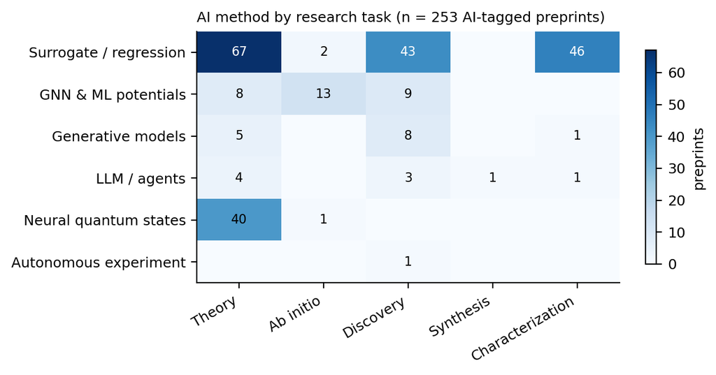

Figure 4: AI-method usage by mode of inquiry across the working corpus. Synthesis carries a single record, and it comes from the supplement: the systematic seed has none. The figure combines 120 seed records with 133 from the targeted supplement, so 53% of it was retrieved by keyword rather than sampled systematically. It therefore describes the AI-for-superconductivity literature this survey assembled, not an adoption rate; the rate is the seed-only 1.2% quoted above.

## 5.2 Predicting *T*<sub>*c*</sub>, and what the screening pipelines actually deliver

The oldest and densest thread predicts *T*<sub>*c*</sub> from composition or structure. Its anchors predate this survey’s window: a composition-based classifier and regressor trained on the SuperCon database (Stanev et al. 2018), and a widely reused statistical model built on chemical-formula features (Hamidieh 2018). Both are honest about scope. The latter predicts a transition temperature only for materials already known to superconduct, which is a different problem from finding new ones.

Within the window, the productive form of this thread is not the regressor alone but the regressor used as a filter in front of density-functional perturbation theory. The clearest example screens roughly 200,000 metallic compounds on or near the convex hull with a model trained on about 7,000 electron-phonon calculations, validates the survivors with first-principles calculations, and reports 545 compounds with *T*<sub>*c*</sub> above 10 K (Cerqueira et al. 2023). The same group applied the workflow to ambient- pressure hydrides in a set of more than 150,000 compounds, finding around 50 systems above 20 K, and reported that most of them sit slightly off the convex hull, so synthesis would need conditions away from ambient equilibrium (Cerqueira et al. 2024). A companion study screened over a million compounds and proposed the thermodynamically stable Mg<sub>2</sub>XH<sub>6</sub> family, with X = Rh, Ir, Pd or Pt, at 45-80 K and above 100 K with electron doping of the platinum compound (Sanna et al. 2024). A deep-learning framework explored about 36 million ternary hydride structures across 29 elements and identified 144 candidates above 200 K at 200 GPa, 129 of them new (X. Wang et al. 2025).

These are substantial results, and they are all predictions in this survey’s sense. None of the four papers reports a synthesised, measured superconductor. What the machine learning buys is the ratio of candidates examined to calculations run: the model is a cheap surrogate that lets an expensive but trusted method be pointed somewhere useful. That is a real contribution, and it is a narrower one than “AI discovers superconductors” suggests.

## 5.3 Generative and language-model approaches

Generative models entered the field along the path they took in materials science generally, where diffusion models over atom types, coordinates and the periodic lattice became the standard instrument for proposing crystal structures under property constraints (Zeni et al. 2025). An inverse-design workflow combining pre-trained models, diffusion and first-principles calculation reported 74 dynamically stable materials with model-predicted *T*<sub>*c*</sub> at or above 15 K, singling out B<sub>4</sub>CN<sub>3</sub> at 24.08 K under 5 GPa and B<sub>5</sub>CN<sub>2</sub> at 15.93 K at ambient pressure (Han et al. 2025). The same engine later proposed cubic Li<sub>2</sub>AuH<sub>6</sub>, with a calculated ambient-pressure *T*<sub>*c*</sub> near 140 K and a suggested synthesis route from LiAu and LiH (Ouyang et al. 2025). Again: calculated, not measured.

Language models arrived more recently and in two distinct roles. The first is extraction. A language-model workflow built an experimental database of 78,203 records covering 19,058 unique compositions from the literature, then fine-tuned open-source models to classify superconductors, predict *T*<sub>*c*</sub>, and generate compositions conditioned on a target *T*<sub>*c*</sub> (Itani et al. 2025). The fine-tuned models performed comparably to feature-based baselines and sometimes better; 28% of the generated compositions were novel; applying the predictors to the GNoME database (Merchant et al. 2023) surfaced unreported candidates above 10 K. The authors label these candidates unverified, which is the correct description and a rarer one than it should be.

The second role is orchestration. An agentic framework couples a billion-parameter atomic model for numerical work to language models for planning, rediscovers 66 experimentally verified superconductors absent from the SuperCon3D database, and screens 2.4 million equilibrium crystals in 28 GPU hours (Li et al. 2026). It then does the thing the rest of this literature does not: four proposed compounds were synthesised and measured – Zr<sub>3</sub>ScRe<sub>8</sub> at *T*<sub>*c*</sub> = 6.5 K, HfZrRe<sub>4</sub> at 5.9 K, Zr<sub>4</sub>VRe<sub>7</sub> at 3.5 K, and Hf<sub>21</sub>Re<sub>25</sub> at 2.5 K. These transition temperatures are low, and that is the point worth holding onto. The loop closed on compounds an order of magnitude below the temperatures the screening papers advertise.

It is not the only closed loop in the window. Four cycles of prediction, experimental test and retraining more than doubled the success rate of superconductor discovery, found a new superconductor in the Zr-In-Ni system, and recovered five superconductors absent from the training data (Pogue et al. 2022). That work satisfies all three parts of this survey’s definition of an AI-found superconductor, and it does the one thing the more recent case does not, which is feed the measurement back into the model. We therefore do not claim these two are the only such loops in the field: they are the ones this corpus surfaced, and no exhaustive search for closed loops was attempted. What both share is the regime they closed in – low-temperature intermetallics at ambient pressure, where the synthesis is routine.

## 5.4 Neural quantum states and the theory side

The largest AI-tagged mode in the corpus is theory, and within it neural quantum states are the most self-contained thread. Building on the demonstration that neural networks can represent many-body wavefunctions (Carleo and Troyer 2017), recent work has pushed the ansatz toward the models superconductivity actually cares about: the two-dimensional *t*-*J* model at finite doping (Lange et al. 2024), the *t*-*t*<sup>′</sup> Hubbard model with symmetry-preserving architectures (Rende et al. 2026), and the Hofstadter-Hubbard model at scale (Roth et al. 2026). This thread is unusual in the survey because its validation is internal: a variational energy can be compared against other methods without anyone growing a crystal. That is precisely why it moves faster than the rest.

## 5.5 Characterization: the quiet, working case

Characterization is where machine learning is least discussed and most routinely useful. The pattern is a model that turns an instrument’s raw output into a physical quantity: unsupervised learning of nematicity from scanning-tunnelling data on magic-angle bilayer graphene (Taranto et al. 2022), convolutional networks detecting charge jumps in superconducting qubits in real time (Gaytan-Villarreal et al. 2026), and machine-learned qubit readout deployed on FPGAs for mid-circuit measurement (Vora et al. 2024; Otting et al. 2026). These papers rarely present themselves as AI-for-science. They are instrument engineering, they are validated against a ground truth the instrument already provides, and they work.

## 5.6 The critical literature

Three strands of criticism bear directly on how the results above should be read, and a survey that omitted them would misrepresent the field.

The first is about what a computational “discovery” is worth. Examining the claims of the GNoME work, Cheetham and Seshadri report “scant evidence for compounds that fulfill the trifecta of novelty, credibility, and utility”, and conclude that while the methods hold promise there is “a great need to incorporate domain expertise in materials synthesis and crystallography” (Cheetham and Seshadri 2024). The second concerns autonomous synthesis. The A-Lab report is usually cited for a single number, and the number needs care: 41 of 58 targets were realised autonomously over 17 days of operation, and 43 products in total once runs with human intervention are included (Szymanski et al. 2023). Taking that work as their example, Leeman and co-workers examined all 43 synthetic products, identified four recurring shortfalls in the analysis, and concluded that no new materials had been discovered in it (Leeman et al. 2024). A subsequent author correction narrowed the novelty claim to materials that were “new to the prediction platform, not necessarily new to science”, reported that a peer-reviewed re-analysis of the diffraction data upheld 36 of 40 re-examined successes with four inconclusive, and removed one compound, Zn<sub>2</sub>Cr<sub>3</sub>FeO<sub>8</sub>, that had mistakenly been present in the training data (Szymanski et al. 2026). The three claims – novelty, correct identification of the phases made, and autonomous execution – have to be judged separately, and the training-data leakage is a small instance of the label problem this survey returns to below. Neither critique says the programme is worthless. Both say the validation step is where the difficulty lives, which is the same thing this survey’s corpus says about superconductivity specifically.

The third strand is superconductivity’s own reproducibility record, and it is unusually harsh. Two prominent claims in this field’s recent history were retracted: room-temperature superconductivity in carbonaceous sulfur hydride (Snider et al. 2020) and near-ambient superconductivity in nitrogen-doped lutetium hydride (Dasenbrock-Gammon et al. 2023). The LK-99 episode (Lee, J.-H. Kim, et al. 2023) generated a burst of replication attempts visible as a spike in this corpus’s 2023Q3 activity. On the theoretical side, first-principles work found no stable near-ambient phase in the Lu-N-H system capable of supporting high-*T*<sub>*c*</sub> superconductivity, while identifying metastable templates at higher pressure (Fang et al. 2024). The relevant point for this survey is structural: a field whose flagship experimental claims have repeatedly failed replication is a field where a model’s training labels are unreliable in exactly the high-*T*<sub>*c*</sub> region where the predictions matter most.

## 5.7 Assessment

Machine learning in superconductivity is currently, in the main, a way of making expensive calculations cheaper and instrument data more usable. It has in a small number of documented cases also guided the discovery of experimentally confirmed superconductors (Pogue et al. 2022; Li et al. 2026), and that remains the exception rather than the mode. The evidence for that reading is the shape of the corpus rather than any single paper: 1.2% penetration in the systematic seed, no AI-tagged synthesis paper in it, and closed loops that delivered intermetallics at 2.5 to 6.5 K with no applied pressure reported, while the screening literature advertises predictions above 200 K at 200 GPa. The two numbers describe different regimes, and the point is not that one refutes the other: the loop closed where the synthesis was routine and stays open where the headline predictions live. The next section asks, cell by cell, what would have to change.

# 6 An AI-readiness assessment

## 6.1 What is being scored, and what it is not

Section 5 described what has happened. This section asks what could. Figure 5 scores three properties on a 0-3 scale and names the constraint that currently binds, for 15 of the taxonomy’s 45 cells: the ones the preceding sections discussed at length. Iron-based systems and the other unconventional families are not scored, and the unscored cells should not be read as scoring zero – they are cells this survey did not examine closely enough to rate.

*Data availability* asks whether enough machine-readable, labelled data exists to train or evaluate a model. Benchmark maturity asks whether a shared task with an agreed metric and a held-out set exists, so that two methods can be compared without re-running each other’s pipelines. Cheap validation asks what it costs to find out whether a prediction was right – a score of 3 means a calculation settles it, a 0 means a hard experiment is required. The binding bottleneck names which of data, compute, theory or experiment is the constraint that would have to move first.

These scores are the author’s judgement, not measurements, and they should be read as a structured argument rather than as data. Their unweighted sum is used to order the display; it is not an estimate of scientific value or of expected return on effort. They are stated on a coarse scale precisely because a finer one would imply a precision that is not there. The corpus counts inform them but do not determine them: a cell can be crowded and unready, and Section 8 argues that several are.

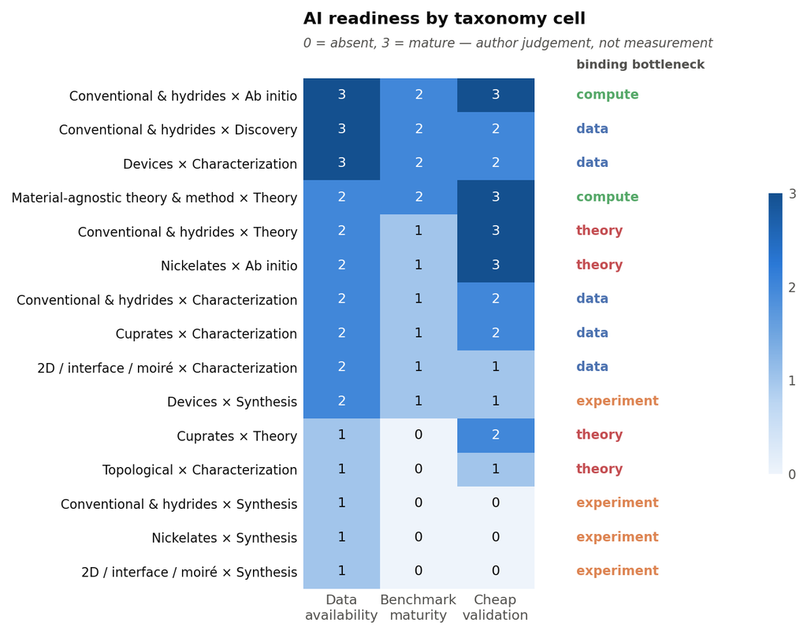

Figure 5: AI readiness for 15 of the taxonomy’s 45 cells – the ones Sections 3 and 4 discuss at length. Scores are the author’s judgement on a 0-3 scale, not measurements; unscored cells are unrated, not zero-rated; the appendix states the reasoning for each scored cell.

## 6.2 The three regimes

Read down Figure 5 and the cells sort into three groups.

*Cheap-validation cells, where progress is fastest and already visible.* Conventional and hydride ab initio work scores highest: a machine-readable training set exists – about 7,000 electron-phonon calculations assembled to screen roughly 200,000 compounds in the largest such study (Cerqueira et al. 2023) – an accepted target quantity exists in the Eliashberg *T*<sub>*c*</sub>, and a prediction can be checked by running the calculation the model was trained to approximate. Material-agnostic theory sits alongside it: a neural quantum state’s variational energy is checkable against other methods on the same Hamiltonian. Both cells are compute-limited rather than data-limited, and both are where the corpus already shows the most AI activity. This is not a coincidence, and it is the single strongest regularity in the survey: *machine learning has penetrated exactly those cells where a machine can grade its own homework.*

*Data-limited cells, where the obstacle is that measurements are not in a usable form.* Characterization across cuprates, hydrides, two-dimensional systems and devices falls here. The raw material is abundant – decades of ARPES, scanning tunnelling, transport and neutron data – but in the papers read for this survey it reached the reader as figures inside PDFs, in per-group formats, and in supplementary files without schemas. As Section 4 says, we did not audit data-availability practice across the field, and this scoring rests on that reading rather than on a survey of release policies. The one recent large-scale attempt to fix this for superconductivity extracted 78,203 records with a language-model workflow (Itani et al. 2025), which is both an encouraging result and a measure of how absent such resources were. Device characterization scores best in this group because qubit and detector metrology already produces standardised, high-volume, machine-generated data, which is why the working applications in Section 5 cluster there.

*Experiment-limited cells, where nothing else is the bottleneck.* The conventional, nickelate and two-dimensional synthesis cells all score 1, 0, 0. There is no shared dataset of attempted syntheses with their outcomes, no benchmark, and validation requires making the material. Device synthesis is the one exception, at 2, 1, 1, because semiconductor-style fabrication generates process data even where little of it is published. The corpus carries the corresponding signature: no AI-tagged synthesis paper in the 10,049-record seed, and one in the merged corpus of 10,249. This is where the general AI-for-materials programme has invested most visibly, in autonomous laboratories (Szymanski et al. 2023), and where the criticism has been sharpest (Leeman et al. 2024). Superconductivity makes the problem harder than the oxide-powder case those systems target: nickelate films require topotactic reduction, hydrides require diamond anvil cells at hundreds of gigapascals, and moiré devices require stacking with angular precision. None of these is a pipetting robot’s problem.

## 6.3 Where the theory bottleneck sits

Machine learning can still contribute in these cells, and the corpus shows how: not by predicting *T*<sub>*c*</sub> but by solving the models themselves. Neural quantum states applied to the *t*-*J* and Hubbard models (Lange et al. 2024; Rende et al. 2026) address the theory bottleneck directly, because the obstacle there is the cost of solving a well-posed problem rather than the absence of a label.

## 6.4 What the ranking implies

Ordering the 15 scored cells by summed score produces a priority list, and it is not the list the field’s activity implies. The highest-scoring opportunities are ab initio screening, device characterization and material-agnostic theory – two of which are barely discussed in the machine-learning-for-superconductors literature, which concentrates instead on composition-to-*T*<sub>*c*</sub> regression. The lowest-scoring are the synthesis cells, which is where AI-for-materials rhetoric concentrates most heavily.

The ends of that ordering are more robust than its middle. Conventional ab initio scores at least as high as every other cell on all three axes, so it stays first under any non-negative weighting; the synthesis cells stay last for the same reason. The three cells tied at seven change places as soon as one axis is weighted above another, and none of this tests the scores themselves, only what follows from them. Readiness in this sense is also not the same as value: a cell can be ready and unimportant, and the ordering says nothing about the cost of acting on it.

Three consequences follow, and each is a claim that could be checked rather than a prediction we are confident in.

*Characterization inversion is the most under-exploited opportunity.* Spectroscopic and microscopy data is abundant, the mapping from spectrum to physical parameter is well-posed, and validation is cheap because independent measurements of the same sample exist. What is missing is not method but infrastructure: standardised, openly-released, labelled spectra. This is a dataset problem that a coordinated effort could solve in a way that no amount of model development will.

*Synthesis will not yield to autonomous laboratories in this field on the current design.* The binding constraint is that superconductivity’s important syntheses are extreme-condition and low-throughput. The tractable version of the problem is narrower and more useful: predicting whether a computationally proposed compound can be made at all. The screening literature already generates this need – one study noted that most of its promising ambient-pressure hydrides sit slightly off the convex hull (Cerqueira et al. 2024) – and a synthesizability model trained on attempted syntheses, including the failures, would be worth more to that pipeline than another increment of *T*<sub>*c*</sub>-regression accuracy.

*The field needs a held-out benchmark with experimental resolution.* No cell in Figure 5 scores 3 on benchmark maturity. The screening papers cannot be compared against each other, because each reports its own candidate list validated by its own calculations. A benchmark built from post-2024 experimentally confirmed superconductors, with predictions time-stamped before confirmation, would separate methods that generalise from methods that interpolate their training set. The retraction record (Snider et al. 2020; Dasenbrock-Gammon et al. 2023) makes the label quality problem acute, and therefore makes the benchmark more valuable, not less.

## 6.5 Assessment

The pattern across the scored cells is that AI adoption in this field lines up with validation cost better than with data volume or scientific importance. Where a calculation can check a prediction, methods have arrived. Where an experiment is needed, they have not, regardless of how much has been written about the cell. This is a correspondence between two things the survey observes, not a controlled comparison: we did not measure validation cost independently of adoption, and Section 8 states it as a hypothesis with the evidence that would test it. The three priorities that follow are stated above; each is a dataset or standards problem rather than a modelling one, which is why none of them is glamorous.

# 7 Outlook: a route to the grail, and what it requires

The preceding sections are deliberately deflationary. This one is not, but it earns its optimism by being specific about what would have to be built.

The target is easy to state and has been stated for a century: a superconductor that works at room temperature and ambient pressure, in a material that can be made in quantity. Every partial success so far has failed one of those three conditions. Cuprates and nickelates reach high temperatures but not room temperature. Hydrides reach near-room temperature but only under megabar pressure, and the claims that went further were retracted (Snider et al. 2020; Dasenbrock-Gammon et al. 2023). Nothing in the AI literature surveyed in Section 5 has moved any of the three constraints.

We take one recent industrial development as *framing* rather than as evidence, and say so explicitly: Anthropic’s preview of a Model Hardware Standard, a shared specification through which AI agents drive laboratory instruments directly (Anthropic 2026). It is a product announcement, not a peer-reviewed result, and we cite it for what it signals about where infrastructure is heading rather than for any claim about superconductivity. What it signals matters here, because Section 6 identified experiment as the binding constraint in every synthesis cell. That section did not isolate instrument integration as the cause of that constraint, and nothing in this survey measures integration cost separately from synthesis time, sample yield or the cost of a failed run; the argument below is about a plausible lever on a constraint the corpus does establish, not a measured one.

## 7.1 Why the missing piece is the instrument interface, not the model

The argument of this survey has been that AI penetrated superconductivity exactly where a machine could grade its own work, and stopped where a physical experiment was required. That boundary is not a statement about model capability. It is a statement about what a model is connected to.

Three developments now bear on that boundary simultaneously. Autonomous-laboratory software has matured from bespoke scripts toward operating systems with typed, stateful device abstractions (Gao et al. 2025), and the field now frames its next phase around six properties – interoperable, collaborative, generalizable, orchestrated, safe and creative – rather than around isolated robotic cells (Lee et al. 2026). Multi-agent orchestration of laboratory resources is being studied as a management problem in its own right (Kusne and McDannald 2026). And hardware-standardisation efforts aim to collapse instrument integration from weeks to hours (Anthropic 2026).

If these hold, the practical consequence for superconductivity is narrow and important: the cost of *one experimental iteration* falls, and with it the cost of the validation step that Figure 5 identifies as the binding constraint in every synthesis cell. Nothing about that requires a better *T*<sub>*c*</sub> regressor.

## 7.2 Four things that would have to be built

*A synthesizability model trained on failures.* Section 4 established that the negative half of the synthesis record does not exist: papers report the attempts that worked. The screening literature has already generated the demand – candidate lists in the hundreds, with thermodynamic stability as the only filter, and a known caveat that promising compounds often sit slightly off the convex hull (Cerqueira et al. 2024). A registry of attempted syntheses with conditions and outcomes, failures included, is a coordination problem rather than a research problem, and it is the single highest-leverage dataset this survey can identify. Autonomous platforms are attractive here for a reason usually left implicit: a robot has no incentive to withhold a failed run. Instrumented synthesis generates the negative data that human publication practice systematically destroys.

*Instrumented characterization as a first-class output.* The same argument applies one step downstream. Section 6 ranked characterization inversion as the most under-exploited opportunity in the field, blocked by data format rather than by method. An instrument operating under a machine interface emits arrays with acquisition parameters attached by construction. The dataset problem and the automation problem have the same solution, and the automation is being built for other reasons.

*Extreme-condition autonomy, which is the hard case.* Superconductivity’s important syntheses are not pipetting. They are diamond anvil cells at 200 GPa, topotactic reduction with calcium hydride, molecular-beam epitaxy under strain, and mechanical stacking with angular precision. Existing autonomous platforms target bulk oxide powders, and even there the claims have been contested (Leeman et al. 2024). The honest statement is that no current self-driving laboratory addresses the syntheses this field actually needs, and that closing that gap is an instrumentation programme measured in years. Hardware standardisation does not remove it either: the Model Hardware Standard preview states that it does not yet work with hardware lacking a programming interface (Anthropic 2026), which is a fair description of most extreme-condition apparatus. We suggest, as a judgement rather than a result, that the diamond-anvil-cell case is the one worth attacking first: the sample is tiny, the measurement is electrical, the parameter space is low-dimensional, and the iteration appears to us to be gated largely by human attention. We have not measured that, and a comparison of candidate platforms would need documented integration effort, throughput and failure rates.

*A benchmark with experimental resolution.* The AI-for-science field has begun building serious evaluations – agent suites over research tasks (Bragg et al. 2025), physics-specific research benchmarks (Miao et al. 2026), reproduction of Nature-family results (Wang et al. 2026), and particle-physics analysis reproduction (Faroughy et al. 2026). Superconductivity has none. The version this field needs is specific: a time-stamped registry in which candidate materials are predicted before synthesis, and scored against what is subsequently made and measured. A benchmark of that shape tests one specific thing – whether a method’s ranking holds up on materials confirmed after its predictions were fixed – which retrospective scoring on a fixed dataset cannot, and its absence is why no cell in Figure 5 scores full marks on benchmark maturity. Chronological separation is not the same as distributional separation: a time-stamped benchmark shows that a prediction preceded its confirmation, and a claim about extrapolating away from the training distribution would need chemical or structural held-out splits as well.

## 7.3 What would falsify the optimism

A position paper argues that agentic AI systems, whatever their capabilities as co-scientists, are not built for autonomous discovery – problem selection is distorted by what is measurable, and the loop from hypothesis to validated result is not closed by adding autonomy (Bisht et al. 2026). This survey’s corpus is consistent with that argument rather than against it, and the failure mode it predicts is specific enough to watch for.

If the optimistic route is wrong, it will look like this: instrument standardisation arrives, throughput rises, and the field produces more measurements of the compounds it was already going to measure, while the candidate lists generated by screening remain unsynthesised because the syntheses that matter stay bespoke. Cheap iteration would then have accelerated the cells that were never the bottleneck. The early indicator is measurable in this survey’s own terms: if the AI-tagged synthesis count stays near one while AI-tagged characterization grows, automation has been absorbed by the mode that was already tractable.

The complementary risk is that the loop closes on the wrong targets. The closed prediction-synthesis-measurement loops this survey found delivered low-temperature intermetallics – 2.5 to 6.5 K with no applied pressure reported in the more recent case (Li et al. 2026), a new Zr-In-Ni compound in the earlier one (Pogue et al. 2022) – compounds whose synthesis is routine, which is part of why the loop could close at all. A faster loop that stays in that regime would be a genuine engineering achievement and no progress toward the grail, because the constraint at high *T*<sub>*c*</sub> is not iteration speed but extreme-condition synthesis and the absence of a theory that says where to look in the correlated families.

## 7.4 The honest statement of the route

Putting Sections 4 through 7 together, the route this survey supports is not “apply a generative model to composition space.” It is the three priorities of Section 6, with one step placed alongside them. The four can be pursued in parallel; the dependencies below are about what makes each easier, not about a required order:

1. *Capture the experiments in structured form.* This step is new here, and it feeds the other three: the negative results and the machine-readable characterization records they consume have to come from somewhere, and nothing in current publication practice produces them. Automation is one way to capture them consistently and not the only one; manual and assisted workflows can do it too, given metadata standards, quality control and a release practice.
2. *Build the benchmark*, because without time-stamped experimental resolution the screening literature cannot be compared and therefore cannot improve.
3. *Model synthesizability*, because that is the tractable form of the bottleneck and it converts screening output into experimental input.
4. *Attack the theory bottleneck where it is well-posed*, meaning neural quantum states on the correlated models (Lange et al. 2024; Rende et al. 2026), because in cuprates and nickelates the missing thing is a solved model, not a larger dataset.

Room-temperature ambient-pressure superconductivity may or may not be reachable; that is a question about nature. What this survey can say is that the field’s current allocation of AI effort is not aimed at the steps above, that the steps are buildable with infrastructure now emerging, and that the first three of them are dataset and standards problems rather than modelling problems. That is an unglamorous conclusion, and it is the one the evidence supports.

# 8 Discussion

## 8.1 Reading the corpus’s own shape

Before interpreting any proportion in this survey, three sampling facts have to be stated, because each of them shapes the numbers.

First, the seed is a category harvest, not a topic harvest. A paper appears because its authors chose `cond-mat.supr-con`, so the corpus measures what the community files under superconductivity, which is not identical to what is about superconductivity. The measured off-topic rate within the seed is 2.5%.

Second, the supplement is recency-biased by construction and is excluded from every trend statement and from Table 1’s grid.

Third, labels come from a model pass with 86.3% family and 87.0% mode agreement against a single annotator’s hand labels, and the two smallest modes – synthesis at 7 of 11 and discovery at 5 of 13 – are the least reliable, on denominators small enough that two papers move the rate by fifteen points. Any statement below that depends on those two counts is stated as a hypothesis.

With those caveats, three features of the corpus seem worth explaining.

## 8.2 Three hypotheses about the field’s shape

*The verifiability gradient.* AI methods appear in this corpus almost exactly where a prediction can be checked without an experiment. Ab initio screening, where a DFT calculation grades the model, and neural quantum states, where a variational energy does, are the two populated cells; synthesis, where only a furnace can settle the question, has none in the seed. The hypothesis is that adoption is governed by validation cost rather than by data volume or scientific payoff. It is testable: if it holds, the next AI methods to arrive in this field should show up in characterization inversion tasks, where an independent measurement provides the check, before they show up anywhere in synthesis.

*The label-quality trap at the top of the range.* A *T*<sub>*c*</sub> model is most valuable where *T*<sub>*c*</sub> is highest, and that is precisely where this field’s experimental record is least reliable – two retracted room-temperature claims (Snider et al. 2020; Dasenbrock-Gammon et al. 2023), an unreplicated ambient-pressure claim (Lee, J.-H. Kim, et al. 2023), and continuing methodological dispute about what constitutes proof under megabar pressure (Tallon 2024). The hypothesis is that supervised models in this domain inherit a systematically noisier label distribution in exactly the region they are asked to extrapolate into. This too is testable: a model trained with and without the contested high-*T*<sub>*c*</sub> entries should differ measurably in its top-ranked candidates.

*Category placement: AI-tagged papers are filed as superconductivity papers.* We expected the opposite, and the corpus says otherwise. If AI methods were arriving with machine-learning groups from outside, AI-tagged preprints should be filed under different primary categories from the rest of the corpus. They are not: 68% of AI-tagged seed papers carry `cond-mat.supr-con` as their primary category, against 69% of everything else. What does separate them is reach in the other direction – 16% of AI-tagged papers cross-list to a `cs.*` or `stat.*` category, against 0.3% of the rest, a fifty-fold difference.

These differences describe where authors file their papers. They do not identify disciplinary background, prior expertise, or the direction in which methods travel between communities: arXiv records carry no affiliations, and an earlier draft of this hypothesis asserted the affiliation claim directly, which nothing in this corpus supports. What the category evidence does support is the weaker statement that AI-tagged superconductivity work is being filed as superconductivity work, and reaches outward to computer science rather than arriving from it. Deciding whether methods are taken up internally or imported would need author-level evidence this survey does not have.

None of these is established by this survey. They are the explanations most consistent with the corpus’s shape, offered so that they can be argued with.

## 8.3 What would change the assessment

The three priorities of Section 6 are also the three tests of it, and each fails in a way that would be visible. If a public, standardised corpus of labelled characterization data appeared and the data-limited cells did not move toward method-limited, then format was not what was blocking them. If a registry of attempted syntheses were assembled and synthesizability models trained on it did not improve the hit rate of the screening pipelines, then the missing negative results were not the binding constraint. And if a time-stamped benchmark showed the current screening methods ranking post-2024 experimental confirmations well, then the label-quality problem this survey emphasises is smaller than argued.

We would rather this section be checkable than comprehensive, so we state the prediction it rests on plainly: the assessment in Figure 5 is a claim about validation cost, and it is wrong if AI methods arrive in the experiment-limited cells before the data and benchmark problems in them are solved.

## 8.4 Limitations of this survey

The corpus is arXiv-only and therefore under-represents applied superconductivity published through IEEE venues and industrial device work that is never posted. It is also a category harvest, not a topic harvest, and relevant work filed elsewhere is missed by construction: the agentic screening study discussed in Section 5 is classified `cs.LG` and `cond-mat.mtrl-sci` with no `cond-mat.supr-con` listing (Li et al. 2026), and the scanning-tunnelling study in the same section is filed under `cond-mat.str-el` (Taranto et al. 2022). Both entered through the targeted supplement rather than the seed, which is the clearest available measure of what a single-category harvest costs. The window opens in September 2021, so pre-window developments enter only through hand-verified anchor citations. Labels are single-valued where the underlying reality is often multi-valued, so a paper that synthesises and measures a computationally proposed compound receives one label, and the mode counts do not enumerate the experimental stages inside a study. The AI lens has 88% precision and 77% recall on its validation sample, so the detected rate is more likely to understate AI use than to overstate it; because that sample was stratified on the rule-based tag rather than drawn from the population, we do not report a recall-corrected rate. The AI-readiness scores in Figure 5 are the author’s judgement on a coarse scale, informed by the corpus but not derived from it, and the appendix states the reasoning for each scored cell so that individual scores can be contested. All hand labels were produced by one annotator, so the agreement figures quoted throughout measure consistency between one human pass and one model pass, not accuracy against an external standard.

# 9 Conclusion

This survey mapped five years of superconductivity research – 10,249 arXiv preprints after off-topic filtering – onto two axes, material family and mode of inquiry, and then asked what a machine-learning method could contribute in them.

The mapping produced three findings. Machine learning has barely entered this field: 1.2% of the systematically harvested seed uses an AI method in its own work. Where it has entered, it clusters where predictions can be checked by calculation rather than by experiment – ab initio screening and neural quantum states – and in device metrology, where instruments generate their own labelled data. And the field’s actual bottleneck, synthesis, is the mode with the least usable data and the fewest methods: no AI-tagged paper in the seed, and one in the merged corpus.

The gap between what the screening literature predicts and what has been made and measured is the survey’s most concrete result. Recent screens report candidates above 200 K at 200 GPa; the closed prediction-synthesis-measurement loops this survey found in the window delivered low-temperature intermetallics, 2.5 to 6.5 K with no applied pressure reported in the more recent case (Li et al. 2026; Pogue et al. 2022). The two sit in different regimes, and that is the substance of the gap rather than a caveat to it: the loops closed where the synthesis was easy. Both facts are real, and holding them together is the correct posture toward AI for superconductivity.

For anyone deciding where to apply AI for Science effort in this field, the ordering that follows from the 15 cells scored in Figure 5 is: release labelled characterization data and build inversion models against it; construct a time-stamped benchmark so screening methods can be compared; and model synthesizability rather than attempting to automate synthesis. These are less exciting than inverse-designing a room-temperature superconductor, and they are what the structure of the field currently supports.

# 10 Data availability

The corpus, labels, prompts, hand-labelled validation sets and all scripts are released at https://github.com/deepgrounding/superconductivity-ai-survey. The repository contains the frozen seed harvest (`sc_seed.csv`), the canonical labelled corpus (`sc_corpus_v1.csv`), the raw per-month arXiv responses that reproduce the harvest, the language-model label cache (`llm_labels.jsonl`), the two hand-labelled validation sets (`label_truth.csv`, `ai_label_truth.csv`), and the harvesting, labelling, figure and build scripts. Bibliography entries for corpus papers are generated from the corpus; anchor references outside the harvest window are hand-verified against Crossref and kept separately.

# 11 Appendix: reasoning behind the AI-readiness scores

Figure 5 scores each discussed cell on data availability, benchmark maturity and cheap validation, on a 0-3 scale, and names the binding bottleneck. The scores are the author’s judgement. This appendix states the reasoning so that individual cells can be contested; the scoring table itself is in `build_concept_figures.py`, so a reader who disagrees can change a row and regenerate the figure.

[output not shown]

Aasen, David, Morteza Aghaee, Zulfi Alam, et al. 2025. *Roadmap to Fault Tolerant Quantum Computation Using Topological Qubit Arrays*. https://arxiv.org/abs/2502.12252.

Adiga, Suhas, and Umesh V. Waghmare. 2026. “Accelerating the Search for Superconductors Using Machine Learning.” *Computational Materials Science* 263: 114453. https://doi.org/10.1016/j.commatsci.2025.114453.

Ajeesh, M. O., M. Bordelon, C. Girod, et al. 2023. “The Fate of Time-Reversal Symmetry Breaking in UTe2.” *Physical Review X* 13: 041019. https://doi.org/10.1103/PhysRevX.13.041019.

Anthony-Petersen, Robin, Andreas Biekert, Raymond Bunker, et al. 2024. “A Stress Induced Source of Phonon Bursts and Quasiparticle Poisoning.” *Nature Communications* 15: 6444. https://doi.org/10.1038/s41467-024-50173-8.

Anthropic. 2026. *Previewing the Model Hardware Standard*. Anthropic news post. https://www.anthropic.com/news/model-hardware-standard-research-preview.

Bardeen, J., L. N. Cooper, and J. R. Schrieffer. 1957. “Theory of Superconductivity.” *Physical Review* 108: 1175–204. https://doi.org/10.1103/PhysRev.108.1175.

Bärtl, Florian, Nadia Stegani, Federico Caglieris, et al. 2025. *Evidence of Pseudogap and Absence of Spin Magnetism in the Time-Reversal-Symmetry-Breaking State of Ba<sub>1 − *x*</sub>k<sub>*x*</sub>fe<sub>2</sub>as<sub>2</sub>*. https://arxiv.org/abs/2501.11936.

Bednorz, J. G., and K. A. Müller. 1986. “Possible High *T*<sub>*c*</sub> Superconductivity in the Ba-La-Cu-O System.” *Zeitschrift Für Physik B Condensed Matter* 64: 189–93. https://doi.org/10.1007/BF01303701.

Bisht, Harshit, Vinay Kumar, Kevin Maik Jablonka, Mausam, and N. M. Anoop Krishnan. 2026. *Agentic AI Scientists Are Not Built for Autonomous Scientific Discovery*. https://arxiv.org/abs/2605.08956.

Bordin, Alberto, Xiang Li, David van Driel, et al. 2024. “Crossed Andreev Reflection and Elastic Co-Tunneling in a Three-Site Kitaev Chain Nanowire Device.” *Physical Review Letters* 132: 056602. https://doi.org/10.1103/PhysRevLett.132.056602.

Bragg, Jonathan, Mike D’Arcy, Nishant Balepur, et al. 2025. *AstaBench: Rigorous Benchmarking of AI Agents with a Scientific Research Suite*. https://arxiv.org/abs/2510.21652.

Cai, Weizhao, Vasily S. Minkov, Ying Sun, et al. 2023. *Superconductivity Above 180 k in Ca-Mg Ternary Superhydrides at Megabar Pressures*. https://arxiv.org/abs/2312.06090.

Cao, Yuan, Valla Fatemi, Shiang Fang, et al. 2018. “Unconventional Superconductivity in Magic-Angle Graphene Superlattices.” *Nature* 556: 43–50. https://doi.org/10.1038/nature26160.

Cao, Zi-Yu, Seokmin Choi, Liu-Cheng Chen, et al. 2024. *Probing Superconducting Gap in CeH<sub>9</sub> Under Pressure*. https://arxiv.org/abs/2401.12682.

Carleo, Giuseppe, and Matthias Troyer. 2017. “Solving the Quantum Many-Body Problem with Artificial Neural Networks.” *Science* 355: 602–6. https://doi.org/10.1126/science.aag2302.

Cerqueira, Tiago F. T., Yue-Wen Fang, Ion Errea, Antonio Sanna, and Miguel A. L. Marques. 2024. *Searching Materials Space for Hydride Superconductors at Ambient Pressure*. https://arxiv.org/abs/2403.13496.

Cerqueira, Tiago F. T., Antonio Sanna, and Miguel A. L. Marques. 2023. *Sampling the Whole Materials Space for Conventional Superconducting Materials*. https://arxiv.org/abs/2307.10728.

Cheetham, Anthony K., and Ram Seshadri. 2024. “Artificial Intelligence Driving Materials Discovery? Perspective on the Article: Scaling Deep Learning for Materials Discovery.” *Chemistry of Materials* 36: 3490–95. https://doi.org/10.1021/acs.chemmater.4c00643.

Corbae, Elena, Rong Zhang, Cong Li, et al. 2026. “Hund’s Coupling Assisted Orbital-Selective Superconductivity in Ba1-xKxFe2As2.” *Physical Review B* 113: 224517. https://doi.org/10.1103/yry8-qdm6.

Dangić, ore, Peio Garcia-Goiricelaya, Yue-Wen Fang, Julen Ibañez-Azpiroz, and Ion Errea. 2023. “Ab Initio Study of the Structural, Vibrational and Optical Properties of Potential Parent Structures of Nitrogen-Doped Lutetium Hydride.” *Physical Review B* 108: 064517. https://doi.org/10.1103/PhysRevB.108.064517.

Dasenbrock-Gammon, Nathan, Elliot Snider, Raymond McBride, et al. 2023. “Evidence of Near-Ambient Superconductivity in a N-Doped Lutetium Hydride.” *Nature* 615: 244–50. https://doi.org/10.1038/s41586-023-05742-0.

Deng, Hao, Zhijun Song, Ran Gao, et al. 2022. *Titanium Nitride Film on Sapphire Substrate with Low Dielectric Loss for Superconducting Qubits*. https://arxiv.org/abs/2205.03528.

Drimmer, Maxwell, Sjoerd Telkamp, Felix L. Fischer, et al. 2024. *The Effect of Niobium Thin Film Structure on Losses in Superconducting Circuits*. https://arxiv.org/abs/2403.12164.

Drozdov, A. P., M. I. Eremets, I. A. Troyan, V. Ksenofontov, and S. I. Shylin. 2015. “Conventional Superconductivity at 203 Kelvin at High Pressures in the Sulfur Hydride System.” *Nature* 525: 73–76. https://doi.org/10.1038/nature14964.

Drozdov, A. P., P. P. Kong, V. S. Minkov, et al. 2019. “Superconductivity at 250 K in Lanthanum Hydride Under High Pressures.” *Nature* 569: 528–31. https://doi.org/10.1038/s41586-019-1201-8.

Dvir, Tom, Guanzhong Wang, Nick van Loo, et al. 2023. “Realization of a Minimal Kitaev Chain in Coupled Quantum Dots.” *Nature* 614: 445–50. https://doi.org/10.1038/s41586-022-05585-1.

Fang, Yue-Wen, ore Dangić, and Ion Errea. 2024. “Assessing the Feasibility of Near-Ambient Conditions Superconductivity in the Lu-n-h System.” *Communications Materials* 5: 61. https://doi.org/10.1038/s43246-024-00500-9.

Faroughy, Darius A., Sofia Palacios Schweitzer, Ian Pang, Siddharth Mishra-Sharma, and David Shih. 2026. *Collider-Bench: Benchmarking AI Agents with Particle Physics Analysis Reproduction*. https://arxiv.org/abs/2605.13950.

Gao, Jing, Junhan Chang, Haohui Que, et al. 2025. *UniLabOS: An AI-Native Operating System for Autonomous Laboratories*. https://arxiv.org/abs/2512.21766.

Gashmard, H., H. Shakeripour, and M. Alaei. 2025. *AI-Driven Discovery of High-Temperature Superconductors via Materials Genome Initiative and High-Throughput Screening*. https://arxiv.org/abs/2511.03865.

Gaytan-Villarreal, Daniel, Peter Meiring, Daniel Baxter, et al. 2026. *Real-Time Detection of Charge Jumps in Superconducting Qubits with a Convolutional Neural Network*. https://arxiv.org/abs/2607.14293.

Ge, Jun, Pinyuan Wang, Ying Xing, et al. 2024. “Charge-4e and Charge-6e Flux Quantization and Higher Charge Superconductivity in Kagome Superconductor Ring Devices.” *Physical Review X* 14: 021025. https://doi.org/10.1103/PhysRevX.14.021025.

Griffin, Sinéad M. 2023. *Origin of Correlated Isolated Flat Bands in Copper-Substituted Lead Phosphate Apatite*. https://arxiv.org/abs/2307.16892.

Gu, Yuhao, Congcong Le, Zhesen Yang, Xianxin Wu, and Jiangping Hu. 2025. “Effective Model and Pairing Tendency in Bilayer Ni-Based Superconductor La<sub>3</sub>ni<sub>2</sub>o<sub>7</sub>.” *Physical Review B* 111: 174506. https://doi.org/10.1103/PhysRevB.111.174506.

Hamidieh, Kam. 2018. “A Data-Driven Statistical Model for Predicting the Critical Temperature of a Superconductor.” *Computational Materials Science* 154: 346–54. https://doi.org/10.1016/j.commatsci.2018.07.052.

Han, Xiao-Qi, Zhenfeng Ouyang, Peng-Jie Guo, Hao Sun, Ze-Feng Gao, and Zhong-Yi Lu. 2025. “InvDesFlow: An AI-Driven Materials Inverse Design Workflow to Explore Possible High-Temperature Superconductors.” *Chinese Physics Letters* 42: 047301. https://doi.org/10.1088/0256-307X/42/4/047301.

Holleis, Ludwig, Caitlin L. Patterson, Yiran Zhang, et al. 2025. “Nematicity and Orbital Depairing in Superconducting Bernal Bilayer Graphene with Strong Spin Orbit Coupling.” *Nature Physics* 21: 444–50. https://doi.org/10.1038/s41567-024-02776-7.

Hou, Zhiyong, Zhiyuan Shang, Wen Duan, Wei Xie, Huan Yang, and Hai-Hu Wen. 2025. *Distinct Modulation Behavior of Superconducting Coherence Peaks Associated with Sign-Reversal Gaps in FeTe<sub>0.55</sub>se<sub>0.45</sub>*. https://arxiv.org/abs/2512.01703.

Hu, Yong, Xianxin Wu, Brenden R. Ortiz, et al. 2022. “Coexistence of Tri-Hexagonal and Star-of-David Pattern in the Charge Density Wave of the Kagome Superconductor AV<sub>3</sub>sb<sub>5</sub>.” *Physical Review B* 106: L241106. https://doi.org/10.1103/PhysRevB.106.L241106.

Iguchi, Yusuke, Ruby Shi, Kunihiro Kihou, et al. 2023. “Observation of Superconducting Vortices Carrying a Temperature-Dependent Fraction of the Flux Quantum.” *Science* 380: 1244–47. https://doi.org/10.1126/science.abp9979.

Itani, Suman, Yibo Zhang, Ranjit Itani, and Jiadong Zang. 2025. *Large Language Models for Superconductor Discovery*. https://arxiv.org/abs/2512.10847.

Jiang, Kun, Tao Wu, Jia-Xin Yin, et al. 2022. “Kagome Superconductors AV<sub>3</sub>sb<sub>5</sub> (a=k, Rb, Cs).” *National Science Review* 10: nwac199. https://doi.org/10.1093/nsr/nwac199.

Kamihara, Yoichi, Takumi Watanabe, Masahiro Hirano, and Hideo Hosono. 2008. “Iron-Based Layered Superconductor La[O<sub>1 − *x*</sub>F<sub>*x*</sub>]FeAs (*x* = 0.05–$0.12$) with *T*<sub>*c*</sub> = 26 K.” *Journal of the American Chemical Society* 130: 3296–97. https://doi.org/10.1021/ja800073m.

Kang, Mingu, Shiang Fang, Jonggyu Yoo, et al. 2022. “Charge Order Landscape and Competition with Superconductivity in Kagome Metals.” *Nature Materials*, ahead of print. https://doi.org/10.1038/s41563-022-01375-2.

Kochan, Denis, Andreas Costa, Iaroslav Zhumagulov, and Igor Žutić. 2023. *Phenomenological Theory of the Supercurrent Diode Effect: The Lifshitz Invariant*. https://arxiv.org/abs/2303.11975.

Kusne, A. Gilad, and Austin McDannald. 2026. “Managing Autonomous Materials Labs with Multi-Agent AI and Its Implications for the Science of Science.” *Communications Materials* 7: 173. https://doi.org/10.1038/s43246-026-01219-5.

Lange, Hannah, Annika Böhler, Christopher Roth, and Annabelle Bohrdt. 2024. *Simulating the Two-Dimensional t-j Model at Finite Doping with Neural Quantum States*. https://arxiv.org/abs/2411.10430.

Lau, Liam L. H., and Piers Coleman. 2025. “Topological Mixed Valence Model for Twisted Bilayer Graphene.” *Physical Review X* 15: 021028. https://doi.org/10.1103/PhysRevX.15.021028.

Lee, Heeseung, Hyuk Jun Yoo, Hye Su Jang, Byeongho Park, Yang Jeong Park, and Sang Soo Han. 2026. “Toward Self-Driving Laboratory 2.0 for Chemistry and Materials Discovery.” *Materials Horizons* 13: 4712–39. https://doi.org/10.1039/D5MH01984B.

Lee, Sukbae, Jihoon Kim, Hyun-Tak Kim, Sungyeon Im, SooMin An, and Keun Ho Auh. 2023. *Superconductor Pb<sub>10 − *x*</sub>cu<sub>*x*</sub>(PO<sub>4</sub>)<sub>6</sub>o Showing Levitation at Room Temperature and Atmospheric Pressure and Mechanism*. https://arxiv.org/abs/2307.12037.

Lee, Sukbae, Ji-Hoon Kim, and Young-Wan Kwon. 2023. *The First Room-Temperature Ambient-Pressure Superconductor*. https://arxiv.org/abs/2307.12008.

Leeman, Josh, Yuhan Liu, Joseph Stiles, et al. 2024. “Challenges in High-Throughput Inorganic Materials Prediction and Autonomous Synthesis.” *PRX Energy* 3: 011002. https://doi.org/10.1103/PRXEnergy.3.011002.

Li, Danfeng, Kyuho Lee, Bai Yang Wang, et al. 2019. “Superconductivity in an Infinite-Layer Nickelate.” *Nature* 572: 624–27. https://doi.org/10.1038/s41586-019-1496-5.

Li, Feiyu, Zhenfang Xing, Di Peng, et al. 2025. “Bulk Superconductivity up to 96 k in Pressurized Nickelate Single Crystals.” *Nature* 649: 871–78. https://doi.org/10.1038/s41586-025-09954-4.

Li, Mingze, Yu Rong, Songyou Li, et al. 2026. *Agentic Fusion of Large Atomic and Language Models to Accelerate Superconductor Discovery*. https://arxiv.org/abs/2604.23758.

Lotfizadeh, Neda, William F. Schiela, Barış Pekerten, et al. 2024. “Superconducting Diode Effect Sign Change in Epitaxial Al-InAs Josepshon Junctions.” *Communications Physics* 7: 120. https://doi.org/10.1038/s42005-024-01618-5.

Luo, Zhihui, Xunwu Hu, Meng Wang, Wéi Wú, and Dao-Xin Yao. 2023. “Bilayer Two-Orbital Model of La<sub>3</sub>ni<sub>2</sub>o<sub>7</sub> Under Pressure.” *Physical Review Letters* 131: 126001. https://doi.org/10.1103/PhysRevLett.131.126001.

Mazin, Igor I. 2025. “Notes on Altermagnetism and Superconductivity.” *AAPPS Bulletin* 35: 18. https://doi.org/10.1007/s43673-025-00158-6.

Mazur, G. P., N. van Loo, D. van Driel, et al. 2022. *The Gate-Tunable Josephson Diode*. https://arxiv.org/abs/2211.14283.

Merchant, Amil, Simon Batzner, Samuel S. Schoenholz, Muratahan Aykol, Gowoon Cheon, and Ekin Dogus Cubuk. 2023. “Scaling Deep Learning for Materials Discovery.” *Nature* 624: 80–85. https://doi.org/10.1038/s41586-023-06735-9.

Miao, Tingjia, Wenkai Jin, Muhua Zhang, et al. 2026. *PRL-Bench: A Comprehensive Benchmark Evaluating LLMs’ Capabilities in Frontier Physics Research*. https://arxiv.org/abs/2604.15411.

Mohseni, Masoud, Artur Scherer, K. Grace Johnson, et al. 2024. *How to Build a Quantum Supercomputer: Scaling from Hundreds to Millions of Qubits*. https://arxiv.org/abs/2411.10406.

Nadeem, Muhammad, Michael S. Fuhrer, and Xiaolin Wang. 2023. *Superconducting Diode Effect – Fundamental Concepts, Material Aspects, and Device Prospects*. https://arxiv.org/abs/2301.13564.

Otting, Luca, Xiaorang Guo, Emmanouil Giortamis, Benjamin Lienhard, Pramod Bhatotia, and Martin Schulz. 2026. *Multi-Stage Mamba-Based Architecture for Fast and Scalable Superconducting Qubit Readout*. https://arxiv.org/abs/2607.11668.

Ouyang, Zhenfeng, Bo-Wen Yao, Xiao-Qi Han, Peng-Jie Guo, Ze-Feng Gao, and Zhong-Yi Lu. 2025. “High-Temperature Superconductivity in Li<sub>2</sub>AuH<sub>6</sub> Mediated by Strong Electron-Phonon Coupling Under Ambient Pressure.” *Physical Review B* 111: L140501. https://doi.org/10.1103/PhysRevB.111.L140501.

Peng, Shuting, Yulei Han, Yongkai Li, et al. 2025. “Flat Bands and Distinct Density Wave Orders in Correlated Kagome Superconductor CsCr<sub>3</sub>sb<sub>5</sub>.” *Science China Physics, Mechanics & Astronomy* 69: 217412. https://doi.org/10.1007/s11433-025-2773-3.

Pogue, Elizabeth A., Alexander New, Kyle McElroy, et al. 2022. *Closed-Loop Machine Learning for Discovery of Novel Superconductors*. https://arxiv.org/abs/2212.11855.

Puphal, P., M. Y. P. Akbar, M. Hepting, et al. 2023. “Single Crystal Synthesis, Structure, and Magnetism of Pb<sub>10 − *x*</sub>cu<sub>*x*</sub>(PO<sub>4</sub>)<sub>6</sub>o.” *APL Materials* 11: 101128. https://doi.org/10.1063/5.0172755.

Ran, Sheng, Chris Eckberg, Qing-Ping Ding, et al. 2019. “Nearly Ferromagnetic Spin-Triplet Superconductivity.” *Science* 365: 684–87. https://doi.org/10.1126/science.aav8645.

Rende, Riccardo, Luciano Loris Viteritti, and Antoine Georges. 2026. *Superconductivity in the t-t’ Hubbard Model from Symmetry-Preserving Neural-Network Quantum States*. https://arxiv.org/abs/2608.12465.

Roth, Christopher, Andrew Millis, and Tomohiro Soejima. 2026. *Large Scale Neural Quantum States Reveal the Interplay Between Superconductivity and Quantum Criticality in the Hofstadter-Hubbard Model*. https://arxiv.org/abs/2608.02753.

Sakakibara, Hirofumi, Naoya Kitamine, Masayuki Ochi, and Kazuhiko Kuroki. 2024. “Possible High t<sub>*c*</sub> Superconductivity in La<sub>3</sub>ni<sub>2</sub>o<sub>7</sub> Under High Pressure Through Manifestation of a Nearly-Half-Filled Bilayer Hubbard Model.” *Physical Review Letters* 132: 106002. https://doi.org/10.1103/PhysRevLett.132.106002.

Salke, Nilesh P., Alexander C. Mark, Muhtar Ahart, and Russell J. Hemley. 2023. *Evidence for Near Ambient Superconductivity in the Lu-n-h System*. https://arxiv.org/abs/2306.06301.

Sánchez, Jazmín Aragón, Raúl Cortés Maldonado, María Lourdes Amigó, Gladys Nieva, Alejandro Kolton, and Yanina Fasano. 2023. “Disordered Hyperuniform Vortex Matter with Rhombic Distortions in FeSe at Low Fields.” *Physical Review B* 107: 094508. https://doi.org/10.1103/PhysRevB.107.094508.

Sanna, Antonio, Tiago F. T. Cerqueira, Yue-Wen Fang, Ion Errea, Alfred Ludwig, and Miguel A. L. Marques. 2024. “Prediction of Ambient Pressure Conventional Superconductivity Above 80K in Thermodynamically Stable Hydride Compounds.” *Npj Computational Materials* 10: 44. https://doi.org/10.1038/s41524-024-01214-9.

Saykin, David R., Camron Farhang, Erik D. Kountz, et al. 2023. “High Resolution Polar Kerr Effect Studies of CsV<sub>3</sub>sb<sub>5</sub>: Tests for Time Reversal Symmetry Breaking Below the Charge Order Transition.” *Physical Review Letters* 131: 016901. https://doi.org/10.1103/PhysRevLett.131.016901.

Schrade, Constantin, Sujit Manna, and Mathias S. Scheurer. 2026. *Altermagnetic Superconducting Diode Effect from Non-Collinear Compensated Magnetism in Mn<sub>3</sub>pt*. https://arxiv.org/abs/2601.03348.

Semenok, Dmitrii, Jianning Guo, Di Zhou, et al. 2023. *Evidence for Pseudogap Phase in Cerium Superhydrides: CeH<sub>10</sub> and CeH<sub>9</sub>*. https://arxiv.org/abs/2307.11742.

Shen, Yang, Mingpu Qin, and Guang-Ming Zhang. 2023. “Effective Bi-Layer Model Hamiltonian and Density-Matrix Renormalization Group Study for the High-Tc Superconductivity in La<sub>3</sub>ni<sub>2</sub>o<sub>7</sub> Under High Pressure.” *Chinese Physics Letters* 40: 127401. https://doi.org/10.1088/0256-307X/40/12/127401.

Snider, Elliot, Nathan Dasenbrock-Gammon, Raymond McBride, et al. 2020. “Room-Temperature Superconductivity in a Carbonaceous Sulfur Hydride.” *Nature* 586: 373–77. https://doi.org/10.1038/s41586-020-2801-z.

Somayazulu, Maddury, Muhtar Ahart, Ajay K. Mishra, et al. 2019. “Evidence for Superconductivity Above 260 K in Lanthanum Superhydride at Megabar Pressures.” *Physical Review Letters* 122: 027001. https://doi.org/10.1103/PhysRevLett.122.027001.

Sommer, Timo, Roland Willa, Jörg Schmalian, and Pascal Friederich. 2022. *3DSC - a New Dataset of Superconductors Including Crystal Structures*. https://arxiv.org/abs/2212.06071.

Song, Yinggang, Chuanheng Ma, Hongbo Wang, et al. 2025. *Room-Temperature Superconductivity at 298 k in Ternary La-Sc-h System at High-Pressure Conditions*. https://arxiv.org/abs/2510.01273.

Stanev, Valentin, Corey Oses, A. Gilad Kusne, et al. 2018. “Machine Learning Modeling of Superconducting Critical Temperature.” *Npj Computational Materials* 4: 29. https://doi.org/10.1038/s41524-018-0085-8.

Sun, Hualei, Mengwu Huo, Xunwu Hu, et al. 2023. “Signatures of Superconductivity Near 80 K in a Nickelate Under High Pressure.” *Nature* 621: 493–98. https://doi.org/10.1038/s41586-023-06408-7.

Szymanski, Nathan J., Bernardus Rendy, Yuxing Fei, et al. 2023. “An Autonomous Laboratory for the Accelerated Synthesis of Inorganic Materials.” *Nature* 624: 86–91. https://doi.org/10.1038/s41586-023-06734-w.

Szymanski, Nathan J., Bernardus Rendy, Yuxing Fei, et al. 2026. “Author Correction: An Autonomous Laboratory for the Accelerated Synthesis of Inorganic Materials.” *Nature* 650: E1. https://doi.org/10.1038/s41586-025-09992-y.

Tallon, Jeffery L. 2024. *Flux-Trapping Experiments on Ultra-High Pressure Hydrides as Evidence of Superconductivity*. https://arxiv.org/abs/2409.12351.

Taranto, William, Samuel Lederer, Youngjoon Choi, et al. 2022. *Unsupervised Learning of Two-Component Nematicity from STM Data on Magic Angle Bilayer Graphene*. https://arxiv.org/abs/2203.04449.

Thorngren, Ryan, Tibor Rakovszky, Ruben Verresen, and Ashvin Vishwanath. 2023. *Higgs Condensates Are Symmetry-Protected Topological Phases: II. U(1) Gauge Theory and Superconductors*. https://arxiv.org/abs/2303.08136.

Tran, Huan, Hieu-Chi Dam, Christopher Kuenneth, Tuoc N. Vu, and Hiori Kino. 2024. “Superconductor Discovery in the Emerging Paradigm of Materials Informatics.” *Chemistry of Materials* 36: 10939–66. https://doi.org/10.1021/acs.chemmater.4c01757.

Tsintzis, Athanasios, Rubén Seoane Souto, Karsten Flensberg, Jeroen Danon, and Martin Leijnse. 2024. “Roadmap Towards Majorana Qubits and Nonabelian Physics in Quantum Dot-Based Minimal Kitaev Chains.” *PRX Quantum* 5: 010323. https://doi.org/10.1103/PRXQuantum.5.010323.

Verresen, Ruben, Umberto Borla, Ashvin Vishwanath, Sergej Moroz, and Ryan Thorngren. 2022. *Higgs Condensates Are Symmetry-Protected Topological Phases: I. Discrete Symmetries*. https://arxiv.org/abs/2211.01376.

Vora, Neel R., Yilun Xu, Akel Hashim, et al. 2024. *ML-Powered FPGA-Based Real-Time Quantum State Discrimination Enabling Mid-Circuit Measurements*. https://arxiv.org/abs/2406.18807.

Wang, Da, Qiang-Hua Wang, and Congjun Wu. 2022. *Symmetry Constraints on Direct-Current Josephson Diodes*. https://arxiv.org/abs/2209.12646.

Wang, Gang, Ningning Wang, Jun Hou, et al. 2024. “Pressure-Induced Superconductivity in Polycrystalline La3Ni2O7.” *Physical Review X* 14: 011040. https://doi.org/10.1103/PhysRevX.14.011040.

Wang, Xiaoyang, Chengqian Zhang, Zhenyu Wang, et al. 2025. *Discovery of High-Temperature Superconducting Ternary Hydrides via Deep Learning*. https://arxiv.org/abs/2502.16558.

Wang, Yuru, Lejun Cheng, Yuxin Zuo, et al. 2026. *NatureBench: Can Coding Agents Match the Published SOTA of Nature-Family Papers?* https://arxiv.org/abs/2606.24530.

Wang, Yuxin, Kun Jiang, Jianjun Ying, et al. 2025. “Recent Progress in Nickelate Superconductors.” *National Science Review* 12: nwaf373. https://doi.org/10.1093/nsr/nwaf373.

Wines, Daniel, Ramya Gurunathan, Kevin F. Garrity, et al. 2023. “Recent Progress in the JARVIS Infrastructure for Next-Generation Data-Driven Materials Design.” *Applied Physics Reviews* 10: 041302. https://doi.org/10.1063/5.0159299.

Wu, Z., T. I. Weinberger, J. Chen, et al. 2024. “Enhanced Triplet Superconductivity in Next Generation Ultraclean UTe2.” *Proceedings of the National Academy of Sciences* 121: e2403067121. https://doi.org/10.1073/pnas.2403067121.

Xu, Chenchao, Siqi Wu, Guo-Xiang Zhi, et al. 2025. “Altermagnetic Ground State in Distorted Kagome Metal CsCr<sub>3</sub>sb<sub>5</sub>.” *Nature Communications* 16: 3114. https://doi.org/10.1038/s41467-025-58446-6.

Xu, Hao, Chia-Min Chung, Mingpu Qin, Ulrich Schollwöck, Steven R. White, and Shiwei Zhang. 2024. “Coexistence of Superconductivity with Partially Filled Stripes in the Hubbard Model.” *Science* 384: eadh7691. https://doi.org/10.1126/science.adh7691.

Yang, Haitao, Yuhan Ye, Zhen Zhao, et al. 2024. “Superconductivity and Orbital-Selective Nematic Order in a New Titanium-Based Kagome Metal CsTi3Bi5.” *Nature Communications* 15: 9626. https://doi.org/10.1038/s41467-024-53870-6.

Yu, Jiabin, Christopher J. Ciccarino, Raffaello Bianco, Ion Errea, Prineha Narang, and B. Andrei Bernevig. 2024. “Nontrivial Quantum Geometry and the Strength of Electron-Phonon Coupling.” *Nature Physics* 20: 1262–68. https://doi.org/10.1038/s41567-024-02486-0.

Zeni, Claudio, Robert Pinsler, Daniel Zügner, et al. 2025. “A Generative Model for Inorganic Materials Design.” *Nature* 639: 624–32. https://doi.org/10.1038/s41586-025-08628-5.

Zhang, Yanan, Dajun Su, Yanen Huang, et al. 2024. “High-Temperature Superconductivity with Zero-Resistance and Strange Metal Behavior in La<sub>3</sub>ni<sub>2</sub>o<sub>7 − *δ*</sub>.” *Nature Physics* 20: 1269–73. https://doi.org/10.1038/s41567-024-02515-y.

Zhang, Yang, Ling-Fang Lin, Thomas A. Maier, and Elbio Dagotto. 2026. *Superconductivity in Ruddlesden-Popper Nickelates: A Review of Recent Progress, Focusing on Thin Films*. https://arxiv.org/abs/2604.18385.

Zhou, Guangdi, Wei Lv, Heng Wang, et al. 2025. “Ambient-Pressure Superconductivity Onset Above 40 k in Bilayer Nickelate Ultrathin Films.” *Nature* 640: 641–46. https://doi.org/10.1038/s41586-025-08755-z.

Zhou, Guangdi, Heng Wang, Haoliang Huang, et al. 2026. “Superconductivity Onset Above 60 k in Ambient-Pressure Nickelate Films.” *National Science Review* 13: nwag151. https://doi.org/10.1093/nsr/nwag151.

Zhou, Yazhou, Jing Guo, Shu Cai, et al. 2023. *Investigations of Key Issues on the Reproducibility of High-Tc Superconductivity Emerging from Compressed La3Ni2O7*. https://arxiv.org/abs/2311.12361.